# **Análisis comparativo de factores socioculturales y económicos que han afectado la longevidad de las personas en la región de América Central (AC) entre los años del 2010 al 2022**

## Preprocesado de datos

```python
import pandas as pd

# Datos obtenidos de https://databank.worldbank.org/reports.aspx?source=world-development-indicators#
with open ("datos.csv", "r") as f:
    lineas = f.read().splitlines()
    rangoDeLineas = lineas[:85]

with open("preprocesado.csv", "w") as f:
    for linea in rangoDeLineas:
        f.write(linea + "\n")

#Leer datos
df = pd.read_csv("preprocesado.csv", sep =",")
df = df.drop(columns=["Series Code", "Country Code"], errors="ignore")
#Limpieza de datos

df.columns = ['País', 'Indicador', '2010', '2011', '2012', '2013', '2014', '2015', '2016', '2017', '2018', '2019', '2020', '2021', '2022']
df
```

|  | País | Indicador | 2010 | 2011 | 2012 | 2013 | 2014 | 2015 | 2016 | 2017 | 2018 | 2019 | 2020 | 2021 | 2022 |
| --- | --- | --- | --- | --- | --- | --- | --- | --- | --- | --- | --- | --- | --- | --- | --- |
| 0 | Panama | Access to electricity (% of population) | 86.9 | 88.6 | 89.300000 | 89.1 | 90.800000 | 91.6 | 92.4 | 93.7 | 93.8 | 93.9 | 95.3 | 95.3 | 95 |
| 1 | Panama | Adjusted net national income per capita (curre... | 7015.42519401087 | 8352.88381575184 | 9470.203419 | 10522.9611933459 | 11017.875258 | 11982.0392200809 | 12440.2690508819 | 13242.292985116 | 13217.7100307791 | 13342.468707283 | 10887.5910897658 | 11830.9871827426 | .. |
| 2 | Panama | Current health expenditure per capita (current... | 608.2467041 | 665.84649658 | 725.863770 | 806.58551025 | 920.076599 | 982.79394531 | 1057.40661621 | 1127.68896484 | 1228.07336426 | 1340.13781738 | 1358.09069824 | 1415.24499512 | .. |
| 3 | Panama | Employment to population ratio, 15+, total (%)... | 59.391 | 59.077 | 60.790000 | 61.487 | 60.933000 | 60.898 | 60.851 | 60.06 | 61.463 | 61.817 | 51.296 | 53.504 | 57.727 |
| 4 | Panama | GDP per capita (current US$) | 8124.55830734871 | 9403.43990821634 | 10767.293179 | 11932.2862205866 | 12837.247958 | 13669.5594424097 | 14382.2323819969 | 15185.9724813803 | 16156.0742859681 | 16472.8317470488 | 13293.3331951688 | 15491.2898013383 | 17357.6286293985 |
| ... | ... | ... | ... | ... | ... | ... | ... | ... | ... | ... | ... | ... | ... | ... | ... |
| 79 | Belize | Labor force, total | 128753 | 133836 | 138977.000000 | 144234 | 151065.000000 | 156821 | 162580 | 166748 | 170728 | 174493 | 172620 | 177472 | 185068 |
| 80 | Belize | Life expectancy at birth, total (years) | 72.272 | 72.651 | 73.245000 | 73.666 | 73.311000 | 73.187 | 73.399 | 73.562 | 73.703 | 73.931 | 72.854 | 70.47 | 70.962 |
| 81 | Belize | Net migration | 1644 | 1583 | 1529.000000 | 1504 | 1452.000000 | 1363 | 1283 | 1222 | 1185 | 1164 | 0 | 577 | 600 |
| 82 | Belize | People using at least basic sanitation service... | 85.6277083290934 | 85.9422379234594 | 86.257854 | 86.5747585957408 | 86.893045 | 87.2129807113852 | 87.534777016108 | 87.8585217818837 | 88.184416079473 | 88.1985036524971 | 88.2142766873075 | 88.23173186587 | 88.2510779331487 |
| 83 | Belize | Population density (people per sq. km of land ... | 14.121262604121 | 14.4470846120123 | 14.776808 | 15.1112669881631 | 15.446515 | 15.7768960982025 | 16.1031565103025 | 16.4266988163086 | 16.7499342393687 | 17.0580885576502 | 17.3135028496274 | 17.537527400263 | .. |

84 rows × 15 columns

### **TAREAS PARA EL PROYECTO:**

1. *Un DataFrame por Indicador:*

   **Bryan**
   - 'Access to electricity (% of population)',
   - 'Adjusted net national income per capita (current US$)'

   **Jaime**
   - 'Current health expenditure per capita (current US$)',
   - 'Employment to population ratio, 15+, total (%) (national estimate)',

   **Nery**
   - 'GDP per capita (current US$)',
   - 'Industry (including construction), value added (% of GDP)',

   **Maria Jose**
   - 'Labor force with advanced education (% of total working-age population with advanced education)',
   - 'Labor force, total',
   - 'Life expectancy at birth, total (years)',

   **Karen**
   - 'Net migration',
   - 'People using at least basic sanitation services (% of population)',
   - 'Population density (people per sq. km of land area)'
2. *Hacer los siguientes gráficos por cada indicador:*
   1. Barras
   2. Líneas

```python
cantidadIndicadores = len(df['Indicador'].unique()) # cantidad de indicadores
cantidadIndicadores, df['Indicador'].unique() # imprime los indicadores
```

```
(12,
 array(['Access to electricity (% of population)',
        'Adjusted net national income per capita (current US$)',
        'Current health expenditure per capita (current US$)',
        'Employment to population ratio, 15+, total (%) (national estimate)',
        'GDP per capita (current US$)',
        'Industry (including construction), value added (% of GDP)',
        'Labor force with advanced education (% of total working-age population with advanced education)',
        'Labor force, total', 'Life expectancy at birth, total (years)',
        'Net migration',
        'People using at least basic sanitation services (% of population)',
        'Population density (people per sq. km of land area)'],
       dtype=object))
```

### Bryan

**- 'Access to electricity (% of population)'**

Puede observarse que los países con un mayor porcentaje de acceso a la electricidad son:

1. Costa Rica
2. El Salvador
3. Belize

Mientras que los paises con menos acceso a electricidad son:

1. Nicaragua
2. Honduras

(Datos tomando como periodo de tiempo [2010 - 2022])

```python
# seleccione las filas que contienen el indicador "Access to electricity (% of population"
dfAccessElectricity = df[df['Indicador'].str.contains('Access to electricity (% of population)', na=False, regex=False)]
# eliminar la columna indicador
dfAccessElectricity  = dfAccessElectricity.drop(columns=['Indicador'])
# elegimos la columna " País" como index y eliminamos la columna "País"
dfAccessElectricity .set_index('País', inplace=True)
# mostramos los datos
dfAccessElectricity
```

| País | 2010 | 2011 | 2012 | 2013 | 2014 | 2015 | 2016 | 2017 | 2018 | 2019 | 2020 | 2021 | 2022 |
| --- | --- | --- | --- | --- | --- | --- | --- | --- | --- | --- | --- | --- | --- |
| Panama | 86.9 | 88.6 | 89.3 | 89.1 | 90.8 | 91.6 | 92.4 | 93.7 | 93.8 | 93.9 | 95.3 | 95.3 | 95 |
| Costa Rica | 99 | 99.2 | 99.5 | 99.6 | 99.4 | 99.4 | 99.5 | 99.6 | 99.7 | 99.7 | 99.9 | 100 | 100 |
| El Salvador | 91.6 | 92.6 | 93.7 | 95 | 95.1 | 95.4 | 96 | 96.8 | 97 | 97.4 | 99.7 | 97.9 | 100 |
| Guatemala | 84.3 | 84 | 86.8 | 88.1 | 85.5 | 90.5 | 91.8 | 93.3 | 94.2 | 95.4 | 96.6 | 97.9 | 99.1 |
| Honduras | 81 | 82.2 | 83.6 | 87.2 | 88.7 | 90 | 91.6 | 86.5 | 91.6 | 91.1 | 93.1 | 94.1 | 94.4 |
| Nicaragua | 80.1 | 81.2 | 81.3 | 81.9 | 81.9 | 83.2 | 83.9 | 84.6 | 85.2 | 85.7 | 86 | 86.3 | 86.5 |
| Belize | 89.9 | 91.7 | 90.9 | 91.1 | 91.5 | 91.8 | 93.3 | 94.2 | 91.7 | 92.7 | 96.8 | 97.7 | 98.6 |

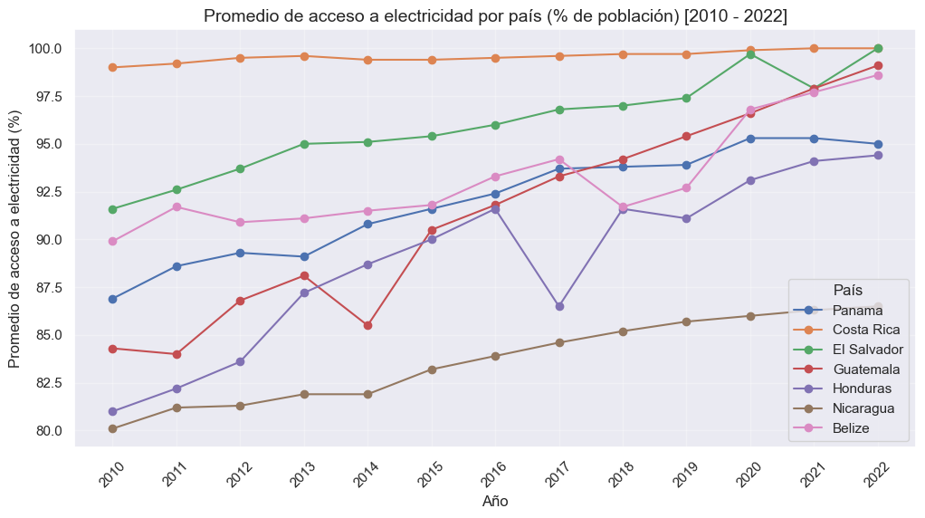

```python
from pyparsing import Regex
import seaborn as sns
import matplotlib.pyplot as plt

# Filtrar por un indicador específico
dfAccessElectricity  = df[df['Indicador'] == "Access to electricity (% of population)"]

# Convertir columnas a numérico y calcular la media por país
dfAccessElectricity .iloc[:, 2:] = dfAccessElectricity .iloc[:, 2:].apply(pd.to_numeric, errors='coerce')
# eliminar la columna indicador
dfAccessElectricity  = dfAccessElectricity .drop(columns=['Indicador'])
# elegimos la columna "País" como index y eliminamos la columna "País"
dfAccessElectricity .set_index('País', inplace=True)

plt.figure(figsize=(12, 6))

for pais in dfAccessElectricity .index:
    plt.plot(dfAccessElectricity .columns, dfAccessElectricity.loc[pais], marker='o', label=pais)

plt.title('Promedio de acceso a electricidad por país (% de población) [2010 - 2022]', fontsize=14)
plt.xlabel('Año', fontsize=12)
plt.ylabel('Promedio de acceso a electricidad (%)', fontsize=12)
plt.xticks(rotation=45)
plt.legend(title='País')
plt.grid(alpha=0.3)
plt.show()
```

Este gráfico ilustra la evolución del porcentaje de acceso a la electricidad por país en Centroamérica entre 2010 y 2022.

En términos generales, todos los países muestran una tendencia creciente en el acceso a la electricidad, lo que refleja un avance significativo en la cobertura de este servicio básico. Costa Rica destaca de manera sobresaliente al mantener una cobertura cercana al 100%, alcanzando el 100% desde 2021 y manteniéndolo durante 2022.

El Salvador también logró llegar al 100% en 2022, uniéndose a Costa Rica en términos de cobertura total. En cambio, Honduras, que se encuentra entre los países con menos acceso, experimentó una caída notable en 2017, cuando su porcentaje de acceso pasó del 91.6% al 86.5%. Esta disminución podría estar relacionada con diversos factores, como problemas de infraestructura, interrupciones en el suministro eléctrico o desafíos en las políticas energéticas nacionales de ese año.

Nicaragua, por otro lado, sigue siendo el país con el menor porcentaje de acceso a la electricidad, aunque muestra una mejora constante a lo largo del tiempo. A pesar de esto, su cobertura sigue siendo inferior al 90%, lo que subraya la necesidad de continuar trabajando en el fortalecimiento de su infraestructura eléctrica para garantizar un acceso más equitativo.

En resumen, aunque hay avances en todos los países, las disparidades en el acceso a la electricidad continúan siendo notorias, con Costa Rica y El Salvador a la vanguardia, y Nicaragua enfrentando los mayores desafíos en este ámbito.

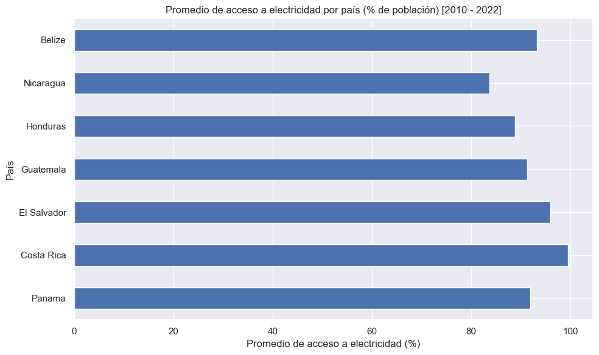

```python
import matplotlib.pyplot as plt

# Convertir todas las columnas (excepto el índice) a valores numéricos
dfAccessElectricity = dfAccessElectricity.apply(pd.to_numeric, errors='coerce')

# Calcular la media de cada fila (promedio por país)
dfAccessElectricity['Media'] = dfAccessElectricity.mean(axis=1)

# Crear el gráfico de barras horizontales para la media de cada país
dfAccessElectricity['Media'].plot(kind='barh', figsize=(10, 6))

# Añadir etiquetas y título
plt.xlabel('Promedio de acceso a electricidad (%)')
plt.ylabel('País')
plt.title('Promedio de acceso a electricidad por país (% de población) [2010 - 2022]')

# Mostrar el gráfico
plt.tight_layout()
plt.show()
```

- Adjusted net national income per capita (current US$)

Mientras que los paises con un menor Ingreso nacional neto ajustado per cápita ($) son:

1. Nicaragua
2. Honduras

(Datos tomando como periodo de tiempo [2010 - 2022])

```python
# seleccione las filas que contienen el indicador "Adjusted net national income per capita (current US$)"
dfPerCapita = df[df['Indicador'].str.contains('Adjusted net national income per capita (current US$)', na=False, regex=False)]
# eliminar la columna indicador
dfPerCapita  = dfPerCapita.drop(columns=['Indicador'])
# elegimos la columna " País" como index y eliminamos la columna "País"
dfPerCapita .set_index('País', inplace=True)
# Reemplazar ".." con NaN para tratar valores faltantes como vacíos
dfPerCapita.replace("..", pd.NA, inplace=True)
# Eliminar columnas completamente vacías (todas las filas NaN)
dfPerCapita = dfPerCapita.dropna(axis=1, how='all')
# mostramos los datos
dfPerCapita
```

| País | 2010 | 2011 | 2012 | 2013 | 2014 | 2015 | 2016 | 2017 | 2018 | 2019 | 2020 | 2021 |
| --- | --- | --- | --- | --- | --- | --- | --- | --- | --- | --- | --- | --- |
| Panama | 7015.42519401087 | 8352.88381575184 | 9470.203419 | 10522.9611933459 | 11017.875258 | 11982.0392200809 | 12440.2690508819 | 13242.292985116 | 13217.7100307791 | 13342.468707283 | 10887.5910897658 | 11830.9871827426 |
| Costa Rica | 7417.77752146118 | 8301.60488959396 | 9109.071521 | 9678.35110519984 | 9736.609781 | 10446.7590407173 | 10786.8880233463 | 10833.4465199305 | 11041.9189987741 | 11300.9351944679 | 10790.5425392728 | 10968.7313742907 |
| El Salvador | 2646.67782274323 | 2931.95467368242 | 3010.034175 | 3028.66630484378 | 3088.366937 | 3181.57824187685 | 3240.60449508984 | 3301.29448742661 | 3395.90889620162 | 3535.0636037592 | 3178.73711096268 | 3676.34957226722 |
| Guatemala | 2417.94636048594 | 2722.66306177561 | 2871.734302 | 3004.24382352275 | 3212.699028 | 3439.84711979065 | 3560.90388718974 | 3791.60178840997 | 3845.29922607009 | 4006.90710748626 | 3977.51225969779 | 4308.91309993237 |
| Honduras | 1636.52385383733 | 1827.70996762527 | 1843.755074 | 1805.12398632364 | 1869.974788 | 1984.10464937445 | 2001.89679001679 | 2127.09307936898 | 2135.61998376748 | 2198.91045137401 | 2096.53419960811 | 2407.05060702826 |
| Nicaragua | 1319.96046969527 | 1438.65318435535 | 1510.682878 | 1539.99866408667 | 1675.731940 | 1774.07898220904 | 1800.67080755003 | 1838.88525572961 | 1717.29591765436 | 1666.97671682866 | 1582.25170903244 | 1694.98665831936 |
| Belize | 3887.56178973155 | 4021.23739523251 | 4175.999757 | 4459.98713877892 | 4621.495523 | 4912.61272933351 | 4869.34818869705 | 4772.05540508598 | 4660.24262821026 | 4787.39752957686 | 4181.93157944865 | 4823.4817941724 |

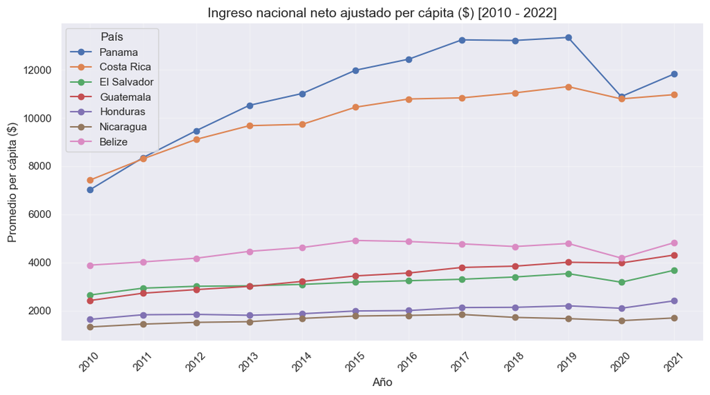

```python
from pyparsing import Regex
import seaborn as sns
import matplotlib.pyplot as plt

# Filtrar por un indicador específico
dfPerCapita = df[df['Indicador'] == "Adjusted net national income per capita (current US$)"]

# Convertir columnas a numérico y calcular la media por país
dfPerCapita.iloc[:, 2:] = dfPerCapita.iloc[:, 2:].apply(pd.to_numeric, errors='coerce')
# eliminar la columna indicador
dfPerCapita = dfPerCapita.drop(columns=['Indicador'])
# elegimos la columna "País" como index y eliminamos la columna "País"
dfPerCapita.set_index('País', inplace=True)

plt.figure(figsize=(12, 6))

for pais in dfPerCapita.index:
    plt.plot(dfPerCapita.columns, dfPerCapita.loc[pais], marker='o', label=pais)

plt.title('Ingreso nacional neto ajustado per cápita ($) [2010 - 2022]', fontsize=14)
plt.xlabel('Año', fontsize=12)
plt.ylabel('Promedio per cápita ($)', fontsize=12)
plt.xticks(rotation=45)
plt.legend(title='País')
plt.grid(alpha=0.3)
plt.show()
```

Este gráfico ilustra la evolución del Ingreso Nacional Neto Ajustado per Cápita ($) en los países de Centroamérica entre 2010 y 2022.

A lo largo de este período, Panamá y Costa Rica destacan como los países con los ingresos más altos, manteniendo una posición dominante en la región. En contraste, Nicaragua y Honduras registran los valores más bajos, evidenciando una notable disparidad económica.

Aunque la mayoría de los países experimentan un crecimiento sostenido en su ingreso nacional neto ajustado per cápita, se observa una caída significativa en 2020, especialmente en Panamá, lo cual parece estar relacionado con los impactos económicos derivados de la pandemia de COVID-19.

Este análisis resalta las marcadas diferencias económicas entre los países de la región, con los más desarrollados como Panamá y Costa Rica manteniendo una brecha considerable frente a los de menor ingreso.

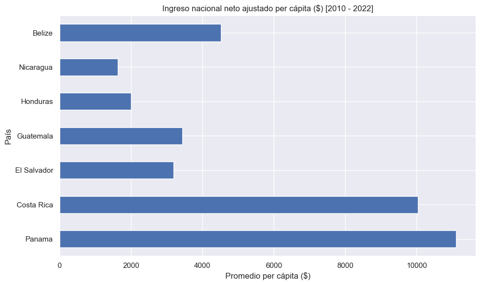

```python
# Convertir todas las columnas (excepto el índice) a valores numéricos
dfPerCapita = dfPerCapita.apply(pd.to_numeric, errors='coerce')

# Calcular la media de cada fila (promedio por país)
dfPerCapita['Media'] = dfPerCapita.mean(axis=1)

# Crear el gráfico de barras horizontales para la media de cada país
dfPerCapita['Media'].plot(kind='barh', figsize=(10, 6))

# Añadir etiquetas y título
plt.xlabel('Promedio per cápita ($)')
plt.ylabel('País')
plt.title('Ingreso nacional neto ajustado per cápita ($) [2010 - 2022]')

# Mostrar el gráfico
plt.tight_layout()
plt.show()
```

### Jaime

- Current health expenditure per capita (current US$) / Gasto sanitario corriente per cápita (US$ corrientes)

En este indicador podemos ver la evolución de la cantidad de dinero que se gasta en salud por persona en los paises de la región, podemos ver por la tabla que el pais con menor desembolso sanitario a sido Nicaragua, y entre los mas grandes estan Costa Rica y Panamá. que se peleaban por los puestos de 2010 a 2013, pero en 2014 Panamá da un boom creciendo mas que los demas paises.

```python
# Seleccionar las filas que contienen el indicador "Current health expenditure per capita (current US$)"
dfHealthExpenditure = df[df['Indicador'].str.contains('Current health expenditure per capita (current US$)', na=False, regex=False)]
# Eliminar la columna 'Indicador'
dfHealthExpenditure = dfHealthExpenditure.drop(columns=['Indicador'])
# Elegir la columna "País" como índice y eliminar la columna "País"
dfHealthExpenditure.set_index('País', inplace=True)
# Reemplazar ".." con NaN para tratar valores faltantes como vacíos
dfHealthExpenditure.replace("..", pd.NA, inplace=True)
# Eliminar columnas completamente vacías (todas las filas NaN)
dfHealthExpenditure = dfHealthExpenditure.dropna(axis=1, how='all')
dfHealthExpenditure
```

| País | 2010 | 2011 | 2012 | 2013 | 2014 | 2015 | 2016 | 2017 | 2018 | 2019 | 2020 | 2021 |
| --- | --- | --- | --- | --- | --- | --- | --- | --- | --- | --- | --- | --- |
| Panama | 608.2467041 | 665.84649658 | 725.863770 | 806.58551025 | 920.076599 | 982.79394531 | 1057.40661621 | 1127.68896484 | 1228.07336426 | 1340.13781738 | 1358.09069824 | 1415.24499512 |
| Costa Rica | 654.17340088 | 742.14190674 | 776.434875 | 816.87872314 | 822.910034 | 875.34973145 | 870.73840332 | 853.75048828 | 902.22119141 | 914.88470459 | 953.08251953 | 948.92163086 |
| El Salvador | 268.66708374 | 293.3677063 | 298.725403 | 321.82662964 | 312.867462 | 329.44250488 | 337.27490234 | 335.73712158 | 345.05181885 | 377.02557373 | 354.48699951 | 442.21374512 |
| Guatemala | 174.79473877 | 190.7144928 | 200.335541 | 198.33766174 | 216.795044 | 233.41566467 | 246.11730957 | 265.18399048 | 265.74734497 | 278.54898071 | 289.1265564 | 340.95812988 |
| Honduras | 163.53704834 | 180.58157349 | 182.423721 | 175.01651001 | 171.304810 | 168.92593384 | 176.97311401 | 168.39216614 | 177.64666748 | 184.03918457 | 212.6973114 | 253.91804504 |
| Nicaragua | 115.32395172 | 122.53475952 | 130.779007 | 137.09841919 | 152.644699 | 161.27700806 | 167.37036133 | 177.15000916 | 168.44512939 | 161.98634338 | 161.19981384 | 198.07792664 |
| Belize | 242.6184082 | 251.19102478 | 246.298172 | 261.2244873 | 296.249390 | 285.84985352 | 292.99127197 | 281.6338501 | 287.60293579 | 298.96051025 | 279.65802002 | 310.19500732 |

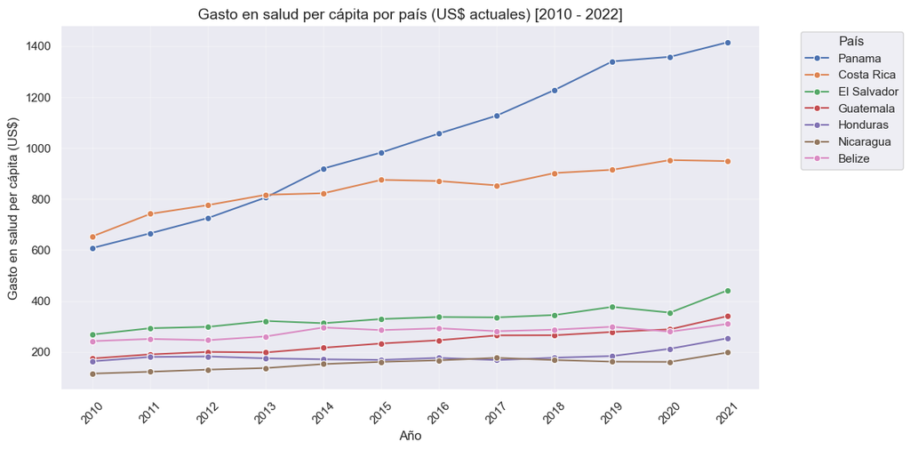

```python
import seaborn as sns
import matplotlib.pyplot as plt
import pandas as pd

# Filtrar por el indicador "Current health expenditure per capita (current US$)"
dfHealthExpenditure = df[df['Indicador'] == "Current health expenditure per capita (current US$)"]

# Convertir columnas a numérico y eliminar la columna 'Indicador'
dfHealthExpenditure.iloc[:, 2:] = dfHealthExpenditure.iloc[:, 2:].apply(pd.to_numeric, errors='coerce')
dfHealthExpenditure = dfHealthExpenditure.drop(columns=['Indicador'])

# Elegir la columna "País" como índice
dfHealthExpenditure.set_index('País', inplace=True)

# Crear el gráfico usando Seaborn y Matplotlib
plt.figure(figsize=(12, 6))

for pais in dfHealthExpenditure.index:
    sns.lineplot(
        x=dfHealthExpenditure.columns,
        y=dfHealthExpenditure.loc[pais],
        marker='o',
        label=pais
    )

# Configuración del gráfico
plt.title('Gasto en salud per cápita por país (US$ actuales) [2010 - 2022]', fontsize=14)
plt.xlabel('Año', fontsize=12)
plt.ylabel('Gasto en salud per cápita (US$)', fontsize=12)
plt.xticks(rotation=45)
plt.legend(title='País', bbox_to_anchor=(1.05, 1), loc='upper left')
plt.grid(alpha=0.3)
plt.tight_layout()
plt.show()
```

Con este grafico podemos ver el comportamiento de gasto de salud para cada uno de los paises contemplando en el eje x los años y en el eje y el desembolso, graficamente vemos que panama y costa rica lideran los puestos y que nicaragua esta en el ultimo puesto similar al analisis anterior. podemos ver los flujos e identificar la tremenda brecha entre los paises de la region central y como estos afrontan esa dificultad.

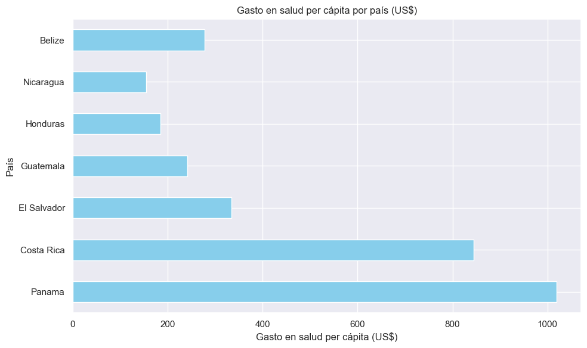

```python
import matplotlib.pyplot as plt
# Convertir todas las columnas (excepto el índice) a valores numéricos
dfHealthExpenditure = dfHealthExpenditure.apply(pd.to_numeric, errors='coerce')

# Calcular la media de cada fila (promedio por país)
dfHealthExpenditure['Media'] = dfHealthExpenditure.mean(axis=1)

# Crear el gráfico de barras horizontales para la media de cada país
dfHealthExpenditure['Media'].plot(kind='barh', color='skyblue', figsize=(10, 6))

# Añadir etiquetas y título
plt.xlabel('Gasto en salud per cápita (US$)')
plt.ylabel('País')
plt.title('Gasto en salud per cápita por país (US$)')

# Mostrar el gráfico
plt.tight_layout()
plt.show()
```

Mediante el grafico de barras se puede visualizar la distribución de los datos, aca vemos como se distribuyen los valores de la tabla de desembolsos y notamos lo que mencionamos antes, los paises de costa rica y panama liderando y Nicaragua en el puesto mas bajo

- Employment to population ratio, 15+, total (%) (national estimate) / Ratio empleo/población, 15+, total (%) (estimación nacional)

Aca ocurre algo, y es que el pais de nicaragua y belice no proporcionan datos, por tanto su grafica podria ser irregular, en un grafico de cajas y bigotes eso se denotaria como unos datos atipicos, pero volviendo al punto del indicador, estamos hablando de una tasa de empleo nacional de 15 años o mas, en donde vemos que esta tasa indicaria que en un pais cierto porcentaje de la poblacion empieza a trabajar a temprana edad,en donde por la poca informacion proporcionada vemos que nicaragua se lleva esa informacion para un par de años, pero en medias de tiempo exactas vemos que este puesto esta para panama y guatemala.

```python
# Seleccionar las filas que contienen el indicador "Employment to population ratio, 15+, total (%) (national estimate)"
dfEmploymentRatio = df[df['Indicador'].str.contains('Employment to population ratio, 15+, total (%) (national estimate)', na=False, regex=False)]
# Eliminar la columna 'Indicador'
dfEmploymentRatio = dfEmploymentRatio.drop(columns=['Indicador'])
# Elegir la columna "País" como índice y eliminar la columna "País"
dfEmploymentRatio.set_index('País', inplace=True)
# Reemplazar ".." con NaN para tratar valores faltantes como vacíos
dfEmploymentRatio.replace("..", pd.NA, inplace=True)
# Eliminar columnas completamente vacías (todas las filas NaN)
dfEmploymentRatio = dfEmploymentRatio.dropna(axis=1, how='all')
dfEmploymentRatio
```

| País | 2010 | 2011 | 2012 | 2013 | 2014 | 2015 | 2016 | 2017 | 2018 | 2019 | 2020 | 2021 | 2022 |
| --- | --- | --- | --- | --- | --- | --- | --- | --- | --- | --- | --- | --- | --- |
| Panama | 59.391 | 59.077 | 60.790 | 61.487 | 60.933 | 60.898 | 60.851 | 60.06 | 61.463 | 61.817 | 51.296 | 53.504 | 57.727 |
| Costa Rica | 54.968 | 54.85 | 58.472 | 58.43 | 58.734 | 57.523 | 54.861 | 55.223 | 56.604 | 57.318 | 50.666 | 52.416 | 54.527 |
| El Salvador | 58.103 | 58.55 | 59.400 | 59.878 | 58.397 | 57.77 | 57.892 | 57.569 | 57.428 | 58.212 | 56.278 | 57.004 | 58.674 |
| Guatemala | 58.345 | 58.867 | 63.318 | 58.404 | 59.082 | 59.077 | 59.122 | 59.443 | 59.122 | 57.871 | <NA> | 61.569 | 58.403 |
| Honduras | 59.364 | 57.054 | 56.208 | 59.123 | 59.612 | 60.152 | 59.063 | 60.802 | 62.736 | 59.578 | 52.961 | 55.526 | 53.492 |
| Nicaragua | 68.09 | <NA> | 72.947 | 71.72 | 62.034 | <NA> | <NA> | <NA> | <NA> | <NA> | <NA> | <NA> | <NA> |
| Belize | <NA> | <NA> | 57.800 | 57.402 | 58.258 | 58.678 | 59.752 | 59.811 | <NA> | 63.414 | <NA> | <NA> | <NA> |

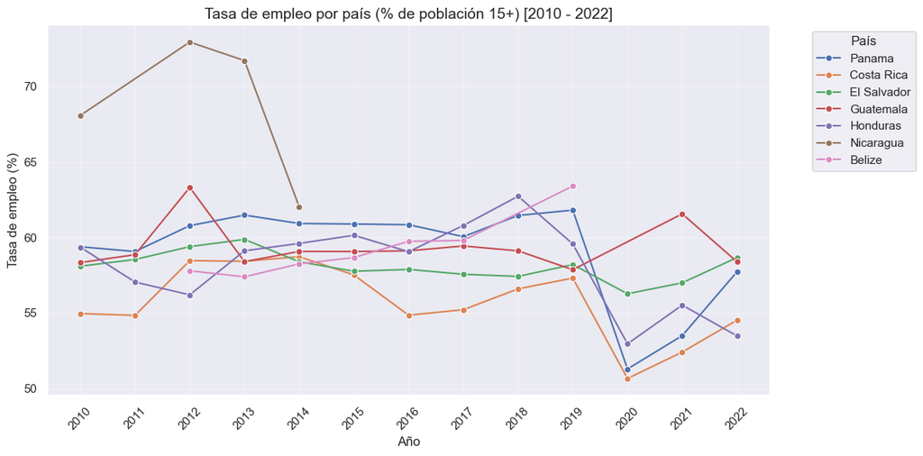

```python
# Filtrar por el indicador "Employment to population ratio, 15+, total (%) (national estimate)"
dfEmploymentRatio = df[df['Indicador'] == "Employment to population ratio, 15+, total (%) (national estimate)"]

# Convertir columnas a numérico y eliminar la columna 'Indicador'
dfEmploymentRatio.iloc[:, 2:] = dfEmploymentRatio.iloc[:, 2:].apply(pd.to_numeric, errors='coerce')
dfEmploymentRatio = dfEmploymentRatio.drop(columns=['Indicador'])

# Elegir la columna "País" como índice
dfEmploymentRatio.set_index('País', inplace=True)

# Crear el gráfico usando Seaborn y Matplotlib
plt.figure(figsize=(12, 6))

for pais in dfEmploymentRatio.index:
    sns.lineplot(
        x=dfEmploymentRatio.columns,
        y=dfEmploymentRatio.loc[pais],
        marker='o',
        label=pais
    )

# Configuración del gráfico
plt.title('Tasa de empleo por país (% de población 15+) [2010 - 2022]', fontsize=14)
plt.xlabel('Año', fontsize=12)
plt.ylabel('Tasa de empleo (%)', fontsize=12)
plt.xticks(rotation=45)
plt.legend(title='País', bbox_to_anchor=(1.05, 1), loc='upper left')
plt.grid(alpha=0.3)
plt.tight_layout()
plt.show()
```

En esta ocasion estamos viendo el grafico respecto a la tas de empleo para los paises de una edad mayor o igual a 15 años, en la figura vemos que nicaragua lidera este grupo pero por la falta de informacion no sabemos su comportamiento para el resto de los periodos, esto implica que este pais recibe personas al ambiente laboral desde temprana edad, quien sabe en que trabajo contraten a menores para algunas tareas y estos cuanto tiempo realizan sus actividades en su vida, pudiendo esforzarse tanto en tan temprana edad afectando su salud y bienestar, pasando de lado los que sabemos de nicaragua, otros paises que podriamos decir que lideran este indicador son Panama y Guatemala, en donde si bien panama de 2019 en adelante bajo este indicador, representa una tasa similar o una tendencia similar a la de GUatemala, no tan cercana pero lo suficiente para intuir que ambos paises cada año contratan a gente de 15 años o mas para distintas labores que a su vez pueden afectar su salud y longevidad.

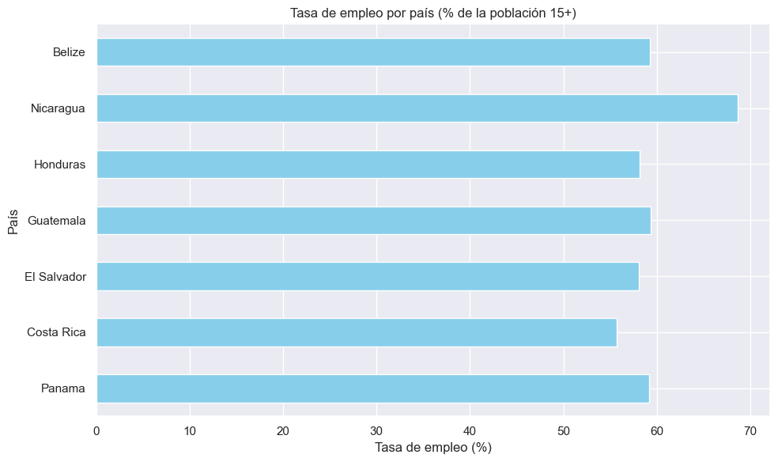

```python
import matplotlib.pyplot as plt
# Convertir todas las columnas (excepto el índice) a valores numéricos
dfEmploymentRatio = dfEmploymentRatio.apply(pd.to_numeric, errors='coerce')

# Calcular la media de cada fila (promedio por país)
dfEmploymentRatio['Media'] = dfEmploymentRatio.mean(axis=1)

# Crear el gráfico de barras horizontales para la media de cada país
dfEmploymentRatio['Media'].plot(kind='barh', color='skyblue', figsize=(10, 6))

# Añadir etiquetas y título
plt.xlabel('Tasa de empleo (%)')
plt.ylabel('País')
plt.title('Tasa de empleo por país (% de la población 15+)')

# Mostrar el gráfico
plt.tight_layout()
plt.show()
```

Nuevamente, en este grafico vemos un promedio respecto a la cantidad de años de la tasa que involucra la tasa de empleo de personas de 15 años o mas, vemos que en promedio nicaragua realiza la mayor tas con cerca de un 70% y guatemala, panama y belice con cerca de un 60%. En el grafico podemos interpretar que para un periodo de 12 años la tasa de empleo es mayor a 50% para todos los paises de centroamerica, siendo asi que para una poblacion, una persona de 15 años podria ser contratado con un alto porcentaje de certeza.

### Nery

-Indicador: GDP per capita (current US$)

Representa la cantidad de dinero que le correspondería a cada habitante del país si se repartiera a todos por igual el PIB generado en un año

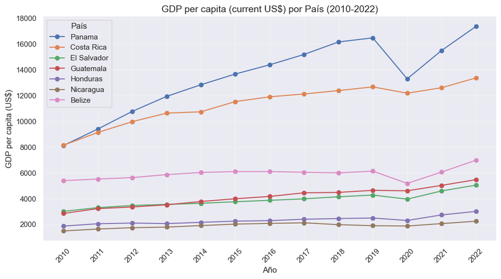

```python
import seaborn as sns
import matplotlib.pyplot as plt

# Filtrar por un indicador específico
dfGPD = df[df['Indicador'] == "GDP per capita (current US$)"]

# Convertir columnas a numérico y calcular la media por país
dfGPD.iloc[:, 2:] = dfGPD.iloc[:, 2:].apply(pd.to_numeric, errors='coerce')
# eliminar la columna indicador
dfGPD = dfGPD.drop(columns=['Indicador'])
# elegimos la columna "País" como index y eliminamos la columna "País"
dfGPD.set_index('País', inplace=True)
#dfGPD

plt.figure(figsize=(12, 6))

for pais in dfGPD.index:
    plt.plot(dfGPD.columns, dfGPD.loc[pais], marker='o', label=pais)

plt.title('GDP per capita (current US$) por País (2010-2022)', fontsize=14)
plt.xlabel('Año', fontsize=12)
plt.ylabel('GDP per capita (US$)', fontsize=12)
plt.xticks(rotation=45)
plt.legend(title='País')
plt.grid(alpha=0.3)
plt.show()
```

Este gráfico muestra la evolución del Producto Interno Bruto (PIB) per cápita en dólares actuales de los países de Centroamérica entre 2010 y 2022.

Panamá y Costa Rica son los países con el PIB per cápita más alto en la región durante todo el período, destacando significativamente sobre el resto. Países como Nicaragua y Honduras tienen los valores más bajos.

Todos los países muestran una tendencia al alza en el PIB per cápita, lo que sugiere un crecimiento económico general durante este período. Sin embargo, en 2020, hay una caída notable en la mayoría de los países (especialmente en Panamá), probablemente relacionada con los efectos económicos de la pandemia de COVID-19.

Las disparidades en PIB per cápita son claras, mostrando que los países más desarrollados económicamente, como Panamá y Costa Rica, mantienen una brecha significativa con respecto a los países de menor ingreso.

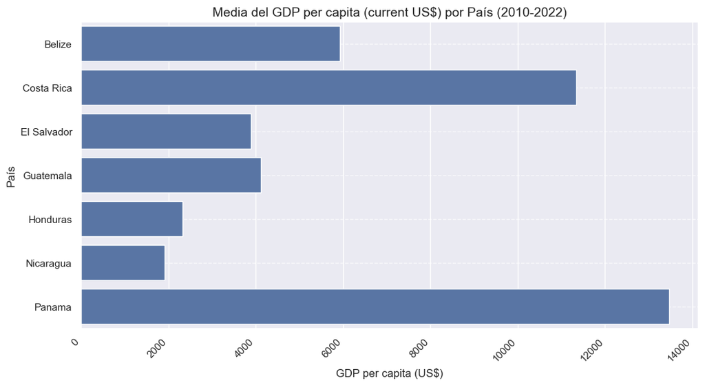

```python
dfGPD_media = dfGPD.groupby('País').mean().mean(axis=1)

# Crear gráfica
plt.figure(figsize=(12, 6))
sns.barplot(y=dfGPD_media.index, x=dfGPD_media.values)

plt.title('Media del GDP per capita (current US$) por País (2010-2022)', fontsize=14)
plt.ylabel('País', fontsize=12)
plt.xlabel('GDP per capita (US$)', fontsize=12)
plt.xticks(rotation=45, ha='right')
plt.grid(axis='y', linestyle='--', alpha=0.7)
plt.show()

plt.show()
```

-Indicador: Industry (including construction), value added (% of GDP)

Se refiere al poncentaje del PIB que aporta el ramo de la industria en general y la construcción a un país

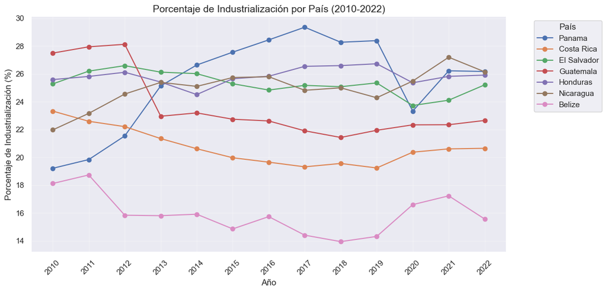

```python
# Filtrar por un indicador específico
dfIndustry = df[df['Indicador'] == "Industry (including construction), value added (% of GDP)"]

# Convertir columnas a numérico y calcular la media por país
dfIndustry.iloc[:, 2:] = dfIndustry.iloc[:, 2:].apply(pd.to_numeric, errors='coerce')
# eliminar la columna indicador
dfIndustry = dfIndustry.drop(columns=['Indicador'])
# elegimos la columna "País" como index y eliminamos la columna "País"
dfIndustry.set_index('País', inplace=True)
#dfIndustry

plt.figure(figsize=(12, 6))

for pais in dfIndustry.index:
    plt.plot(dfIndustry.columns, dfIndustry.loc[pais], marker='o', label=pais)

plt.title('Porcentaje de Industrialización por País (2010-2022)', fontsize=14)
plt.xlabel('Año', fontsize=12)
plt.ylabel('Porcentaje de Industrialización (%)', fontsize=12)
plt.xticks(rotation=45)
plt.legend(title='País', bbox_to_anchor=(1.05, 1), loc='upper left')
plt.grid(alpha=0.3)
plt.show()
```

Este gráfico representa el porcentaje de industrialización (como parte del PIB) de los países de Centroamérica entre 2010 y 2022.

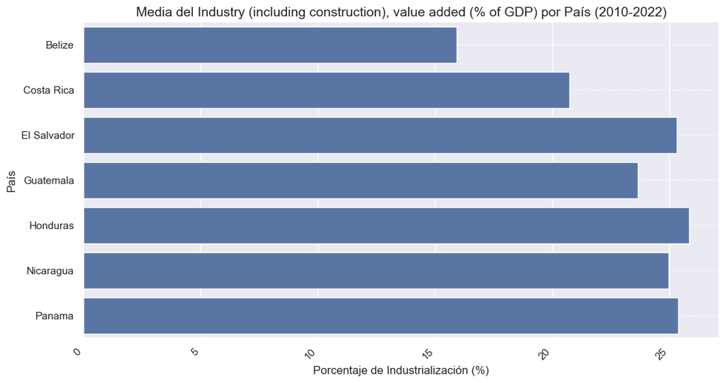

```python
dfIndustry_media = dfIndustry.groupby('País').mean().mean(axis=1)

# Crear gráfica
plt.figure(figsize=(12, 6))
sns.barplot(y=dfIndustry_media.index, x=dfIndustry_media.values)

plt.title('Media del Industry (including construction), value added (% of GDP) por País (2010-2022)', fontsize=14)
plt.ylabel('País', fontsize=12)
plt.xlabel('Porcentaje de Industrialización (%)', fontsize=12)
plt.xticks(rotation=45, ha='right')
plt.grid(axis='y', linestyle='--', alpha=0.7)
plt.show()
```

### Maria Jose

**Labor force with advanced education**

El indicador "Población laboral con educación avanzada" se refiere al porcentaje de la fuerza laboral total que ha alcanzado niveles educativos superiores, como títulos universitarios o postgrados. Este indicador es importante para medir el nivel de educación en la población activa de un país o región, y está relacionado con el tipo de trabajo que las personas pueden realizar y su acceso a mejores oportunidades laborales.

```python
# seleccione las filas que contienen el indicador "Labor force"
dfLaborForce = df[df['Indicador'].str.contains('Labor force with advanced education', na=False)]
# eliminar la columna indicador
dfLaborForce = dfLaborForce.drop(columns=['Indicador'])
# elegimos la columna " País" como index y eliminamos la columna "País"
dfLaborForce.set_index('País', inplace=True)
# mostramos los datos
dfLaborForce
```

| País | 2010 | 2011 | 2012 | 2013 | 2014 | 2015 | 2016 | 2017 | 2018 | 2019 | 2020 | 2021 | 2022 |
| --- | --- | --- | --- | --- | --- | --- | --- | --- | --- | --- | --- | --- | --- |
| Panama | 83.935 | 83.58 | 83.564 | 83.183 | 82.407 | 84.264 | 82.129 | 82.283 | 83.466 | 84.929 | 80.542 | 79.377 | 79.159 |
| Costa Rica | 75.15 | 74.622 | 78.479 | 80.228 | 78.805 | 78.935 | 75.476 | 75.64 | 75.777 | 79.726 | 77.809 | 77.789 | 74.54 |
| El Salvador | 88.485 | 86.659 | 86.049 | 88.687 | 87.390 | 84.195 | 84.345 | 82.344 | 85.487 | 82.694 | 80.301 | 84.883 | 83.6 |
| Guatemala | 87.561 | 85.821 | 87.251 | 85.845 | 79.639 | 85.211 | 82.561 | 82.1 | 81.981 | 81.434 | .. | 84.594 | 81.226 |
| Honduras | 89.467 | 87.715 | 83.379 | 88.862 | 86.198 | 85.718 | 86.74 | 83.604 | 86.308 | 83.443 | .. | 84.298 | 76.802 |
| Nicaragua | .. | .. | 89.965 | .. | 85.640 | .. | .. | .. | .. | .. | .. | .. | .. |
| Belize | .. | .. | 87.710 | 83.753 | 85.712 | 85.64 | 84.545 | 82.79 | .. | 85.427 | .. | .. | .. |

```python
# Reemplazar los valores no numéricos por NaN
dfLaborForce.replace('..', pd.NA, inplace=True)

# Convertir las columnas a float, ignorando los errores
dfLaborForce = dfLaborForce.apply(pd.to_numeric, errors='coerce')
dfLaborForce
```

| País | 2010 | 2011 | 2012 | 2013 | 2014 | 2015 | 2016 | 2017 | 2018 | 2019 | 2020 | 2021 | 2022 |
| --- | --- | --- | --- | --- | --- | --- | --- | --- | --- | --- | --- | --- | --- |
| Panama | 83.935 | 83.580 | 83.564 | 83.183 | 82.407 | 84.264 | 82.129 | 82.283 | 83.466 | 84.929 | 80.542 | 79.377 | 79.159 |
| Costa Rica | 75.150 | 74.622 | 78.479 | 80.228 | 78.805 | 78.935 | 75.476 | 75.640 | 75.777 | 79.726 | 77.809 | 77.789 | 74.540 |
| El Salvador | 88.485 | 86.659 | 86.049 | 88.687 | 87.390 | 84.195 | 84.345 | 82.344 | 85.487 | 82.694 | 80.301 | 84.883 | 83.600 |
| Guatemala | 87.561 | 85.821 | 87.251 | 85.845 | 79.639 | 85.211 | 82.561 | 82.100 | 81.981 | 81.434 | NaN | 84.594 | 81.226 |
| Honduras | 89.467 | 87.715 | 83.379 | 88.862 | 86.198 | 85.718 | 86.740 | 83.604 | 86.308 | 83.443 | NaN | 84.298 | 76.802 |
| Nicaragua | NaN | NaN | 89.965 | NaN | 85.640 | NaN | NaN | NaN | NaN | NaN | NaN | NaN | NaN |
| Belize | NaN | NaN | 87.710 | 83.753 | 85.712 | 85.640 | 84.545 | 82.790 | NaN | 85.427 | NaN | NaN | NaN |

```python
#cambiar filas por columnas de un dataframe
dfLaborForce.T
```

| País | Panama | Costa Rica | El Salvador | Guatemala | Honduras | Nicaragua | Belize |
| --- | --- | --- | --- | --- | --- | --- | --- |
| 2010 | 83.935 | 75.150 | 88.485 | 87.561 | 89.467 | NaN | NaN |
| 2011 | 83.580 | 74.622 | 86.659 | 85.821 | 87.715 | NaN | NaN |
| 2012 | 83.564 | 78.479 | 86.049 | 87.251 | 83.379 | 89.965 | 87.710 |
| 2013 | 83.183 | 80.228 | 88.687 | 85.845 | 88.862 | NaN | 83.753 |
| 2014 | 82.407 | 78.805 | 87.390 | 79.639 | 86.198 | 85.640 | 85.712 |
| 2015 | 84.264 | 78.935 | 84.195 | 85.211 | 85.718 | NaN | 85.640 |
| 2016 | 82.129 | 75.476 | 84.345 | 82.561 | 86.740 | NaN | 84.545 |
| 2017 | 82.283 | 75.640 | 82.344 | 82.100 | 83.604 | NaN | 82.790 |
| 2018 | 83.466 | 75.777 | 85.487 | 81.981 | 86.308 | NaN | NaN |
| 2019 | 84.929 | 79.726 | 82.694 | 81.434 | 83.443 | NaN | 85.427 |
| 2020 | 80.542 | 77.809 | 80.301 | NaN | NaN | NaN | NaN |
| 2021 | 79.377 | 77.789 | 84.883 | 84.594 | 84.298 | NaN | NaN |
| 2022 | 79.159 | 74.540 | 83.600 | 81.226 | 76.802 | NaN | NaN |

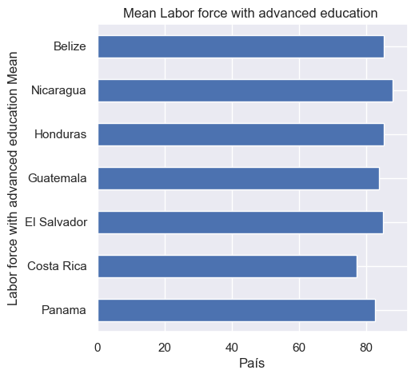

```python
import matplotlib.pyplot as plt
dfLaborForceMean = dfLaborForce.T.mean() #cambiamos filas por columnas y calculamos la media de cada país
#grafico de barras
dfLaborForceMean.plot(kind='barh', title='Mean Labor force with advanced education ', figsize=(5,5), xlabel='País', ylabel='Labor force with advanced education Mean')
```

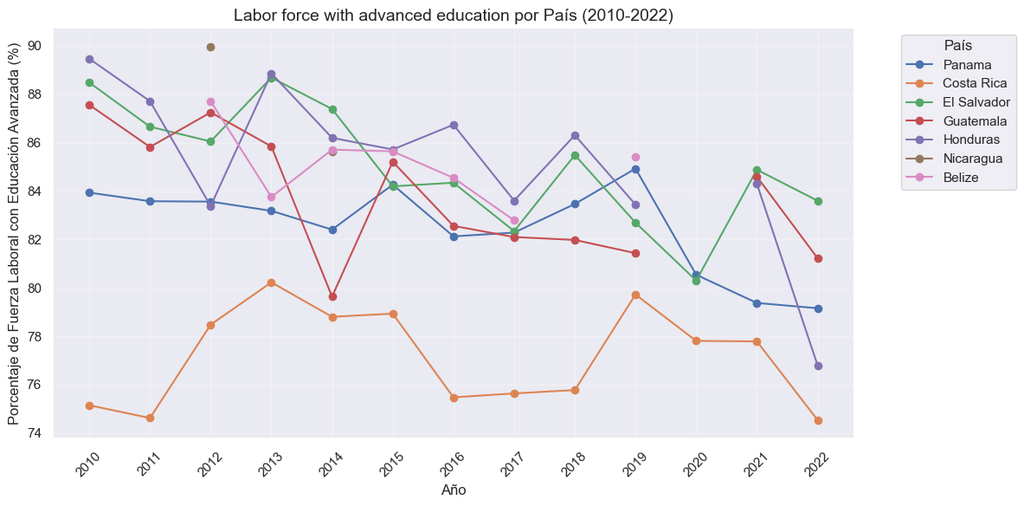

```python
# Transponer para graficar evolución temporal por país
dfLaborForceT = dfLaborForce.T

# Crear el gráfico de líneas
plt.figure(figsize=(12, 6))

for pais in dfLaborForceT.columns:
    plt.plot(dfLaborForceT.index, dfLaborForceT[pais], marker='o', label=pais)

plt.title('Labor force with advanced education por País (2010-2022)', fontsize=14)
plt.xlabel('Año', fontsize=12)
plt.ylabel('Porcentaje de Fuerza Laboral con Educación Avanzada (%)', fontsize=12)
plt.xticks(rotation=45)
plt.legend(title='País', bbox_to_anchor=(1.05, 1), loc='upper left')
plt.grid(alpha=0.3)
plt.tight_layout()
plt.show()
```

El gráfico ayuda a visualizar la relación entre el nivel educativo de la fuerza laboral y la evolución temporal, lo que puede ser relevante en el análisis de cómo la educación influye en las condiciones laborales, la calidad de vida y, en última instancia, en la longevidad de las personas en América Central.

**Tendencias de crecimiento o declive :** Nos permitirá identificar si la proporción de trabajadores con educación avanzada ha aumentado o disminuido en los países durante el período de tiempo analizado.

**Desigualdades entre países :** Podemos observar diferencias en la tasa de trabajadores con educación avanzada entre países de la región. Algunos países pueden mostrar un aumento más pronunciado, mientras que otros pueden estar rezagados.

**Impacto socioeconómico :** Un aumento en la proporción de trabajadores con educación avanzada generalmente refleja mejoras en el acceso a la educación superior y, en muchos casos, se correlaciona con mayores oportunidades de empleo bien remunerado, lo que puede tener un efecto positivo en la calidad de vida y la longevidad.

**Labor force, total**

El indicador "Labour force, total" representa el número total de personas económicamente activas en un país o región. Esto incluye tanto a las personas empleadas como a aquellas que están desempleadas pero buscan trabajo activamente. Es un indicador clave en el análisis de la población en edad de trabajar y la participación en la economía.

```python
# seleccionar las filas que contienen el indicador "Labor force, total"
dfLaborForceTotal = df[df['Indicador'].str.contains('Labor force, total', na=False)]

# eliminar la columna indicador
dfLaborForceTotal = dfLaborForceTotal.drop(columns=['Indicador'])

# elegimos la columna "País" como index y eliminamos la columna "País"
dfLaborForceTotal.set_index('País', inplace=True)

# mostramos los datos
dfLaborForceTotal
```

| País | 2010 | 2011 | 2012 | 2013 | 2014 | 2015 | 2016 | 2017 | 2018 | 2019 | 2020 | 2021 | 2022 |
| --- | --- | --- | --- | --- | --- | --- | --- | --- | --- | --- | --- | --- | --- |
| Panama | 1618269 | 1611450 | 1689370.0 | 1744928 | 1778532.0 | 1813736 | 1859078 | 1885561 | 1966334 | 2041466 | 1929211 | 1996749 | 2049663 |
| Costa Rica | 2060686 | 2149242 | 2321866.0 | 2337155 | 2395003.0 | 2380187 | 2296246 | 2335223 | 2459739 | 2573190 | 2456537 | 2529009 | 2542517 |
| El Salvador | 2494725 | 2517133 | 2579866.0 | 2630753 | 2617260.0 | 2618193 | 2673318 | 2687119 | 2694155 | 2762085 | 2632889 | 2768977 | 2835063 |
| Guatemala | 5253574 | 5486770 | 5980602.0 | 5682211 | 5883588.0 | 6022488 | 6184488 | 6364813 | 6472399 | 6481136 | 6460734 | 6764382 | 7069008 |
| Honduras | 3260247 | 3243536 | 3268694.0 | 3613486 | 3810624.0 | 3919626 | 3983810 | 4161688 | 4431793 | 4399023 | 4206572 | 4452659 | 4564937 |
| Nicaragua | 2442683 | 2512841 | 2583025.0 | 2652874 | 2722579.0 | 2784302 | 2845599 | 2907286 | 2954104 | 2999937 | 3024864 | 3085985 | 3189118 |
| Belize | 128753 | 133836 | 138977.0 | 144234 | 151065.0 | 156821 | 162580 | 166748 | 170728 | 174493 | 172620 | 177472 | 185068 |

```python
# Reemplazar los valores no numéricos por NaN
dfLaborForceTotal.replace('..', pd.NA, inplace=True)

# Convertir los datos a tipo float
dfLaborForceTotal = dfLaborForceTotal.apply(pd.to_numeric, errors='coerce')

# Mostrar los datos
dfLaborForceTotal
```

| País | 2010 | 2011 | 2012 | 2013 | 2014 | 2015 | 2016 | 2017 | 2018 | 2019 | 2020 | 2021 | 2022 |
| --- | --- | --- | --- | --- | --- | --- | --- | --- | --- | --- | --- | --- | --- |
| Panama | 1618269 | 1611450 | 1689370.0 | 1744928 | 1778532.0 | 1813736 | 1859078 | 1885561 | 1966334 | 2041466 | 1929211 | 1996749 | 2049663 |
| Costa Rica | 2060686 | 2149242 | 2321866.0 | 2337155 | 2395003.0 | 2380187 | 2296246 | 2335223 | 2459739 | 2573190 | 2456537 | 2529009 | 2542517 |
| El Salvador | 2494725 | 2517133 | 2579866.0 | 2630753 | 2617260.0 | 2618193 | 2673318 | 2687119 | 2694155 | 2762085 | 2632889 | 2768977 | 2835063 |
| Guatemala | 5253574 | 5486770 | 5980602.0 | 5682211 | 5883588.0 | 6022488 | 6184488 | 6364813 | 6472399 | 6481136 | 6460734 | 6764382 | 7069008 |
| Honduras | 3260247 | 3243536 | 3268694.0 | 3613486 | 3810624.0 | 3919626 | 3983810 | 4161688 | 4431793 | 4399023 | 4206572 | 4452659 | 4564937 |
| Nicaragua | 2442683 | 2512841 | 2583025.0 | 2652874 | 2722579.0 | 2784302 | 2845599 | 2907286 | 2954104 | 2999937 | 3024864 | 3085985 | 3189118 |
| Belize | 128753 | 133836 | 138977.0 | 144234 | 151065.0 | 156821 | 162580 | 166748 | 170728 | 174493 | 172620 | 177472 | 185068 |

```python
#cambiar filas por columnas de un dataframe
dfLaborForceTotal.T
```

| País | Panama | Costa Rica | El Salvador | Guatemala | Honduras | Nicaragua | Belize |
| --- | --- | --- | --- | --- | --- | --- | --- |
| 2010 | 1618269.0 | 2060686.0 | 2494725.0 | 5253574.0 | 3260247.0 | 2442683.0 | 128753.0 |
| 2011 | 1611450.0 | 2149242.0 | 2517133.0 | 5486770.0 | 3243536.0 | 2512841.0 | 133836.0 |
| 2012 | 1689370.0 | 2321866.0 | 2579866.0 | 5980602.0 | 3268694.0 | 2583025.0 | 138977.0 |
| 2013 | 1744928.0 | 2337155.0 | 2630753.0 | 5682211.0 | 3613486.0 | 2652874.0 | 144234.0 |
| 2014 | 1778532.0 | 2395003.0 | 2617260.0 | 5883588.0 | 3810624.0 | 2722579.0 | 151065.0 |
| 2015 | 1813736.0 | 2380187.0 | 2618193.0 | 6022488.0 | 3919626.0 | 2784302.0 | 156821.0 |
| 2016 | 1859078.0 | 2296246.0 | 2673318.0 | 6184488.0 | 3983810.0 | 2845599.0 | 162580.0 |
| 2017 | 1885561.0 | 2335223.0 | 2687119.0 | 6364813.0 | 4161688.0 | 2907286.0 | 166748.0 |
| 2018 | 1966334.0 | 2459739.0 | 2694155.0 | 6472399.0 | 4431793.0 | 2954104.0 | 170728.0 |
| 2019 | 2041466.0 | 2573190.0 | 2762085.0 | 6481136.0 | 4399023.0 | 2999937.0 | 174493.0 |
| 2020 | 1929211.0 | 2456537.0 | 2632889.0 | 6460734.0 | 4206572.0 | 3024864.0 | 172620.0 |
| 2021 | 1996749.0 | 2529009.0 | 2768977.0 | 6764382.0 | 4452659.0 | 3085985.0 | 177472.0 |
| 2022 | 2049663.0 | 2542517.0 | 2835063.0 | 7069008.0 | 4564937.0 | 3189118.0 | 185068.0 |

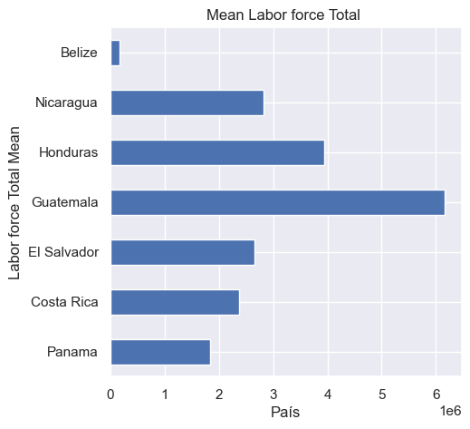

```python
import matplotlib.pyplot as plt
dfLaborForceTotalMean = dfLaborForceTotal.T.mean() #cambiamos filas por columnas y calculamos la media de cada país
#grafico de barras
dfLaborForceTotalMean.plot(kind='barh', title='Mean Labor force Total ', figsize=(5,5), xlabel='País', ylabel='Labor force Total Mean')
```

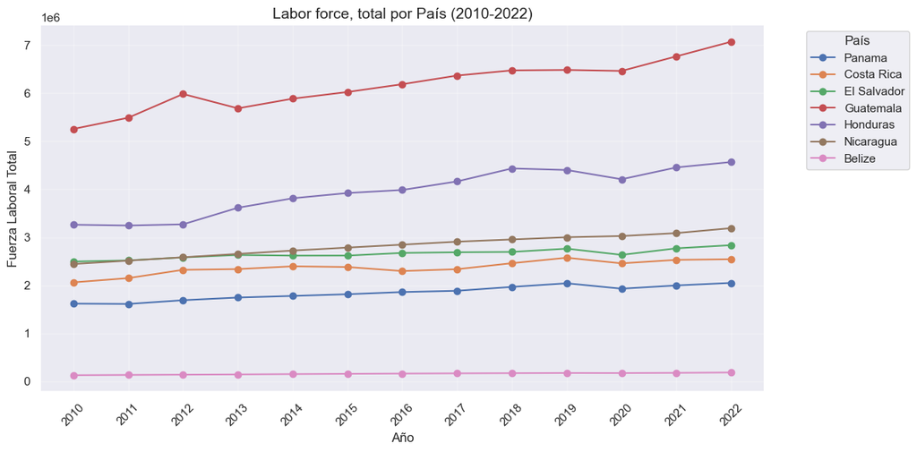

```python
# Transponer para graficar evolución temporal por país
dfLaborForceTotalT = dfLaborForceTotal.T

# Crear el gráfico de líneas
plt.figure(figsize=(12, 6))

for pais in dfLaborForceTotalT.columns:
    plt.plot(dfLaborForceTotalT.index, dfLaborForceTotalT[pais], marker='o', label=pais)

plt.title('Labor force, total por País (2010-2022)', fontsize=14)
plt.xlabel('Año', fontsize=12)
plt.ylabel('Fuerza Laboral Total', fontsize=12)
plt.xticks(rotation=45)
plt.legend(title='País', bbox_to_anchor=(1.05, 1), loc='upper left')
plt.grid(alpha=0.3)
plt.tight_layout()
plt.show()
```

El gráfico de "Labor force, total" nos da una visión clara sobre el tamaño de la fuerza laboral a lo largo del tiempo, lo que nos permite analizar las tendencias económicas, el impacto de las políticas laborales y cómo estos factores afectan la participación de las personas en el mercado laboral. En el contexto de longevidad, un cambio en la fuerza laboral puede estar relacionado con condiciones económicas que afectan la salud, la calidad de vida y, en última instancia, la longevidad de las personas en la región de América Central

**Tendencias en la fuerza laboral :** El gráfico nos permite ver si la fuerza laboral ha crecido, disminuido o permanecido constante en cada país durante el período. Un aumento podría indicar un crecimiento en la población en edad de trabajar o una mayor participación en el mercado laboral.

**Crecimiento económico :** En general, un aumento en el tamaño de la fuerza laboral puede estar relacionado con un crecimiento económico, ya que más personas se integran al mercado laboral. También puede reflejar mejoras en las condiciones laborales o políticas de inclusión.

**Impacto de factores económicos :** Un descenso en la fuerza laboral puede ser un indicador de problemas económicos, como recesión, o de una disminución en la población activa debido a la emigración, el envejecimiento de la población, o la crisis laboral.

**Desigualdad en la participación laboral :**Los países con un crecimiento más pronunciado en su fuerza laboral pueden tener más oportunidades laborales y mejores condiciones socioeconómicas, mientras que aquellos con una disminución podrían enfrentar mayores desafíos en términos de empleo.

**Life expectancy at birth, total**

El indicador "Esperanza de vida al nacer, total (años)" representa el promedio estimado de años que se espera que viva una persona al nacer, suponiendo que las condiciones de mortalidad actuales permanezcan constantes a lo largo de su vida.

```python
# seleccionar las filas que contienen el indicador "Life expectancy at birth, total (years)"
dfLifeExpectancy = df[df['Indicador'].str.contains('Life expectancy at birth, total (years)', na=False, regex=False)]


# eliminar la columna indicador
dfLifeExpectancy = dfLifeExpectancy.drop(columns=['Indicador'])

# elegimos la columna "País" como index y eliminamos la columna "País"
dfLifeExpectancy.set_index('País', inplace=True)

# mostrar los datos
dfLifeExpectancy
```

| País | 2010 | 2011 | 2012 | 2013 | 2014 | 2015 | 2016 | 2017 | 2018 | 2019 | 2020 | 2021 | 2022 |
| --- | --- | --- | --- | --- | --- | --- | --- | --- | --- | --- | --- | --- | --- |
| Panama | 76.448 | 76.627 | 76.819 | 77.038 | 77.248 | 77.468 | 77.653 | 77.795 | 77.863 | 77.81 | 76.657 | 76.223 | 76.826 |
| Costa Rica | 78.67 | 79.348 | 79.283 | 79.403 | 78.774 | 79.086 | 79.459 | 79.377 | 79.484 | 79.427 | 79.277 | 77.023 | 77.32 |
| El Salvador | 71.848 | 71.859 | 71.831 | 71.771 | 71.746 | 71.814 | 72.025 | 72.311 | 72.555 | 72.559 | 71.061 | 70.748 | 71.475 |
| Guatemala | 70.878 | 71.177 | 71.463 | 71.728 | 71.964 | 72.103 | 72.355 | 72.551 | 72.726 | 73.129 | 71.797 | 69.237 | 68.674 |
| Honduras | 71.088 | 71.439 | 71.734 | 71.963 | 72.259 | 72.487 | 72.588 | 72.692 | 72.814 | 72.881 | 71.462 | 70.123 | 70.728 |
| Nicaragua | 72.009 | 72.416 | 72.615 | 72.704 | 72.812 | 72.983 | 73.256 | 73.554 | 73.85 | 74.054 | 71.795 | 73.837 | 74.615 |
| Belize | 72.272 | 72.651 | 73.245 | 73.666 | 73.311 | 73.187 | 73.399 | 73.562 | 73.703 | 73.931 | 72.854 | 70.47 | 70.962 |

```python
# Reemplazar los valores no numéricos por NaN
dfLifeExpectancy.replace('..', pd.NA, inplace=True)

# Convertir los datos a tipo float
dfLifeExpectancy = dfLifeExpectancy.apply(pd.to_numeric, errors='coerce')

# Mostrar los datos
dfLifeExpectancy
```

| País | 2010 | 2011 | 2012 | 2013 | 2014 | 2015 | 2016 | 2017 | 2018 | 2019 | 2020 | 2021 | 2022 |
| --- | --- | --- | --- | --- | --- | --- | --- | --- | --- | --- | --- | --- | --- |
| Panama | 76.448 | 76.627 | 76.819 | 77.038 | 77.248 | 77.468 | 77.653 | 77.795 | 77.863 | 77.810 | 76.657 | 76.223 | 76.826 |
| Costa Rica | 78.670 | 79.348 | 79.283 | 79.403 | 78.774 | 79.086 | 79.459 | 79.377 | 79.484 | 79.427 | 79.277 | 77.023 | 77.320 |
| El Salvador | 71.848 | 71.859 | 71.831 | 71.771 | 71.746 | 71.814 | 72.025 | 72.311 | 72.555 | 72.559 | 71.061 | 70.748 | 71.475 |
| Guatemala | 70.878 | 71.177 | 71.463 | 71.728 | 71.964 | 72.103 | 72.355 | 72.551 | 72.726 | 73.129 | 71.797 | 69.237 | 68.674 |
| Honduras | 71.088 | 71.439 | 71.734 | 71.963 | 72.259 | 72.487 | 72.588 | 72.692 | 72.814 | 72.881 | 71.462 | 70.123 | 70.728 |
| Nicaragua | 72.009 | 72.416 | 72.615 | 72.704 | 72.812 | 72.983 | 73.256 | 73.554 | 73.850 | 74.054 | 71.795 | 73.837 | 74.615 |
| Belize | 72.272 | 72.651 | 73.245 | 73.666 | 73.311 | 73.187 | 73.399 | 73.562 | 73.703 | 73.931 | 72.854 | 70.470 | 70.962 |

```python
#cambiar filas por columnas de un dataframe
dfLifeExpectancy.T
```

| País | Panama | Costa Rica | El Salvador | Guatemala | Honduras | Nicaragua | Belize |
| --- | --- | --- | --- | --- | --- | --- | --- |
| 2010 | 76.448 | 78.670 | 71.848 | 70.878 | 71.088 | 72.009 | 72.272 |
| 2011 | 76.627 | 79.348 | 71.859 | 71.177 | 71.439 | 72.416 | 72.651 |
| 2012 | 76.819 | 79.283 | 71.831 | 71.463 | 71.734 | 72.615 | 73.245 |
| 2013 | 77.038 | 79.403 | 71.771 | 71.728 | 71.963 | 72.704 | 73.666 |
| 2014 | 77.248 | 78.774 | 71.746 | 71.964 | 72.259 | 72.812 | 73.311 |
| 2015 | 77.468 | 79.086 | 71.814 | 72.103 | 72.487 | 72.983 | 73.187 |
| 2016 | 77.653 | 79.459 | 72.025 | 72.355 | 72.588 | 73.256 | 73.399 |
| 2017 | 77.795 | 79.377 | 72.311 | 72.551 | 72.692 | 73.554 | 73.562 |
| 2018 | 77.863 | 79.484 | 72.555 | 72.726 | 72.814 | 73.850 | 73.703 |
| 2019 | 77.810 | 79.427 | 72.559 | 73.129 | 72.881 | 74.054 | 73.931 |
| 2020 | 76.657 | 79.277 | 71.061 | 71.797 | 71.462 | 71.795 | 72.854 |
| 2021 | 76.223 | 77.023 | 70.748 | 69.237 | 70.123 | 73.837 | 70.470 |
| 2022 | 76.826 | 77.320 | 71.475 | 68.674 | 70.728 | 74.615 | 70.962 |

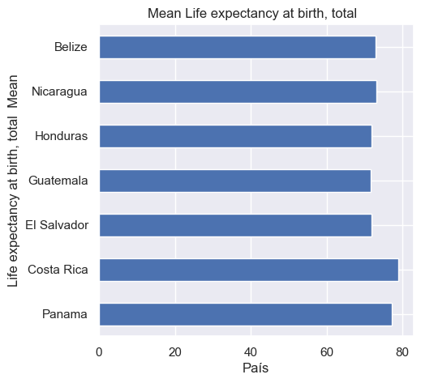

```python
import matplotlib.pyplot as plt
dfLifeExpectancyMean = dfLifeExpectancy.T.mean() #cambiamos filas por columnas y calculamos la media de cada país
#grafico de barras
dfLifeExpectancyMean.plot(kind='barh', title='Mean Life expectancy at birth, total  ', figsize=(5,5), xlabel='País', ylabel='Life expectancy at birth, total  Mean')
```

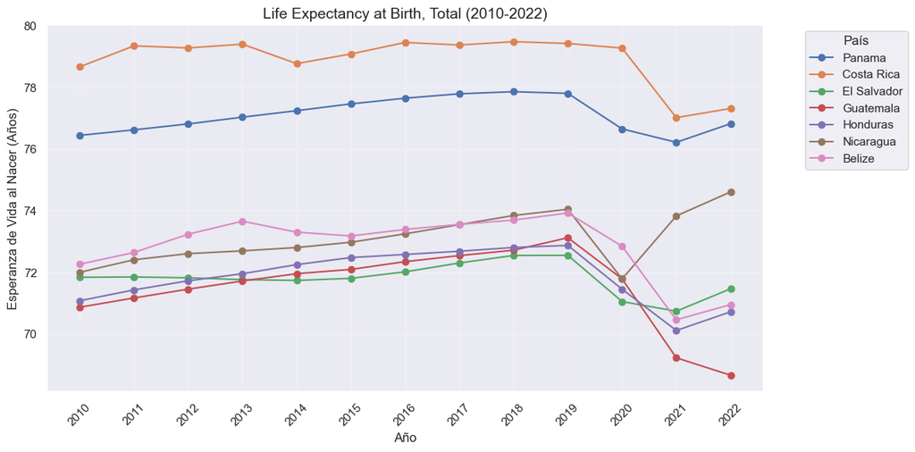

```python
# Transponer para graficar evolución temporal por país
dfLifeExpectancyT = dfLifeExpectancy.T

# Crear el gráfico de líneas
plt.figure(figsize=(12, 6))

for pais in dfLifeExpectancyT.columns:
    plt.plot(dfLifeExpectancyT.index, dfLifeExpectancyT[pais], marker='o', label=pais)

plt.title('Life Expectancy at Birth, Total (2010-2022)', fontsize=14)
plt.xlabel('Año', fontsize=12)
plt.ylabel('Esperanza de Vida al Nacer (Años)', fontsize=12)
plt.xticks(rotation=45)
plt.legend(title='País', bbox_to_anchor=(1.05, 1), loc='upper left')
plt.grid(alpha=0.3)
plt.tight_layout()
plt.show()
```

El gráfico de "Esperanza de vida al nacer, total" ayuda a visualizar cómo ha cambiado la esperanza de vida de la población de un país o región a lo largo del tiempo. Es un indicador clave para entender el bienestar general de la población, las condiciones de salud y los impactos de las políticas públicas. Este gráfico es esencial para evaluar cómo factores socioculturales, económicos y políticos han influido en la longevidad en la región de América Central entre 2010 y 2022.

**Tendencias en la esperanza de vida :** Este gráfico muestra si la esperanza de vida en un país ha aumentado, disminuido o se ha mantenido estable durante el período analizado. En general, un aumento en la esperanza de vida es una señal de mejoras en la salud pública, la atención médica y las condiciones de vida en general.

**Factores socioeconómicos :** Los países con mayores niveles de esperanza de vida suelen tener mejores sistemas de salud, mejores condiciones socioeconómicas y un acceso más equitativo a servicios básicos. Los países con una esperanza de vida más baja pueden enfrentar desafíos como pobreza, acceso limitado a atención médica o alta mortalidad infantil.

**Desigualdad en la esperanza de vida :** Puede mostrar diferencias notables entre países, incluso dentro de una misma región. Las disparidades en la esperanza de vida pueden estar vinculadas a la desigualdad económica, la calidad del sistema de salud, o factores como el acceso a educación y nutrición.

### Karen

- **'Net migration':** En español, migración neta es el número de inmigrantes menos el número de emigrantes, incluidos ciudadanos y no ciudadanos, durante un período determinado. Si el resultado es negativo, significa que hay una disminución en la cantidad de inmigrantes y un aumento en la cantidad de emigrantes. Si el resultado es positivo, significa que hay un aumento en la cantidad de inmigrantes y una disminución en la cantidad de emigrantes.
  - Emigrante es aquel que abandona el país del cual es originario para establecerse en uno nuevo en el extranjero.
  - Inmigrante es aquel que llega a un país distinto de aquel del que es originario con el objetivo de radicarse en él.

```python
# seleccionar las filas que contienen el indicador "Net migration"
dfNetMigration = df[df['Indicador'].str.contains('Net migration')]
# Convertir columnas a numérico y calcular la media por país
dfNetMigration.iloc[:, 2:] = dfNetMigration.iloc[:, 2:].apply(pd.to_numeric, errors='coerce')
# eliminar la columna indicador
dfNetMigration = dfNetMigration.drop(columns=['Indicador'])
# elegimos la columna "País" como index y eliminamos la columna "País"
dfNetMigration.set_index('País', inplace=True)
# mostramos los datos
dfNetMigration
```

| País | 2010 | 2011 | 2012 | 2013 | 2014 | 2015 | 2016 | 2017 | 2018 | 2019 | 2020 | 2021 | 2022 |
| --- | --- | --- | --- | --- | --- | --- | --- | --- | --- | --- | --- | --- | --- |
| Panama | 4953 | 5167 | 5447.0 | 5926 | 7105.0 | 8648 | 10109 | 11059 | 11130 | 10623 | 5473 | 5473 | 7967 |
| Costa Rica | 4728 | 4258 | 3983.0 | 3950 | 3996.0 | 4065 | 4150 | 4196 | 4198 | 4154 | 2084 | 2084 | 3850 |
| El Salvador | -54686 | -53440 | -50554.0 | -49086 | -49130.0 | -51282 | -47499 | -50616 | -54158 | -55143 | -25214 | -27343 | -23249 |
| Guatemala | -36072 | -33204 | -32572.0 | -35666 | -40409.0 | -48162 | -39266 | -48049 | -56884 | -58095 | -23142 | -29118 | -9128 |
| Honduras | -5418 | -5664 | -5896.0 | -6094 | -6302.0 | -6512 | -6685 | -6782 | -6768 | -6550 | -6199 | -5779 | -5374 |
| Nicaragua | -29081 | -28224 | -27388.0 | -26589 | -25571.0 | -24359 | -23081 | -21841 | -20739 | -19733 | -10384 | -10384 | -8000 |
| Belize | 1644 | 1583 | 1529.0 | 1504 | 1452.0 | 1363 | 1283 | 1222 | 1185 | 1164 | 0 | 577 | 600 |

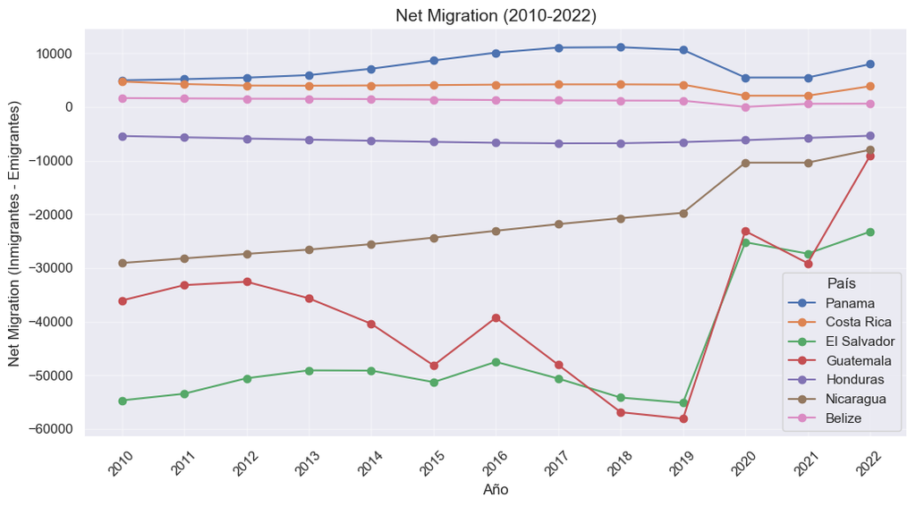

```python
import seaborn as sns
import matplotlib.pyplot as plt

plt.figure(figsize=(12, 6))

for pais in dfNetMigration.index:
    plt.plot(dfNetMigration.columns, dfNetMigration.loc[pais], marker='o', label=pais)

plt.title('Net Migration (2010-2022)', fontsize=14)
plt.xlabel('Año', fontsize=12)
plt.ylabel('Net Migration (Inmigrantes - Emigrantes)', fontsize=12)
plt.xticks(rotation=45)
plt.legend(title='País')
plt.grid(alpha=0.4)
plt.show()
```

El gráfico anterior representa la evolución de la migración neta de la población de cada país centroamericano a través de los años, se puede observar cómo ha incrementado o decrementado la inmigración, y cómo ha decrementado o incrementado la emigración. Cuanto más grande sea la diferencia entre la inmigración y la emigración, más probable es que la población se haya migrado de un país a otro, lo que podría tener implicaciones económicas y sociales en el futuro. Es de tener en cuenta que la migración neta se calcula como la cantidad de inmigrantes menos la cantidad de emigrantes, lo que significa que si el resultado es negativo, hay más personas saliendo de su país de origen que personas entrando a dicho país, mientras que si el resultado es positivo, hay más personas entrando a ese país que personas saliendo a dicho país. Por ejemplo, podemos notar que la migración neta de El Salvador se mantiene negativa a lo largo de los años, lo cual indica que la población de El Salvador ha estado emigrando a otros países en los últimos años, mucho más de lo que han inmigrado al país. Si lo comparamos con Panamá, la migración neta es positiva, lo que indica que Panamá ha sido un país que ha tenido una mayor cantidad de inmigrantes que de emigrantes en los últimos años.

```python
#convertir los datos de tipo objeto a tipo float
dfNetMigration = dfNetMigration.astype(float)
dfNetMigration
```

| País | 2010 | 2011 | 2012 | 2013 | 2014 | 2015 | 2016 | 2017 | 2018 | 2019 | 2020 | 2021 | 2022 |
| --- | --- | --- | --- | --- | --- | --- | --- | --- | --- | --- | --- | --- | --- |
| Panama | 4953.0 | 5167.0 | 5447.0 | 5926.0 | 7105.0 | 8648.0 | 10109.0 | 11059.0 | 11130.0 | 10623.0 | 5473.0 | 5473.0 | 7967.0 |
| Costa Rica | 4728.0 | 4258.0 | 3983.0 | 3950.0 | 3996.0 | 4065.0 | 4150.0 | 4196.0 | 4198.0 | 4154.0 | 2084.0 | 2084.0 | 3850.0 |
| El Salvador | -54686.0 | -53440.0 | -50554.0 | -49086.0 | -49130.0 | -51282.0 | -47499.0 | -50616.0 | -54158.0 | -55143.0 | -25214.0 | -27343.0 | -23249.0 |
| Guatemala | -36072.0 | -33204.0 | -32572.0 | -35666.0 | -40409.0 | -48162.0 | -39266.0 | -48049.0 | -56884.0 | -58095.0 | -23142.0 | -29118.0 | -9128.0 |
| Honduras | -5418.0 | -5664.0 | -5896.0 | -6094.0 | -6302.0 | -6512.0 | -6685.0 | -6782.0 | -6768.0 | -6550.0 | -6199.0 | -5779.0 | -5374.0 |
| Nicaragua | -29081.0 | -28224.0 | -27388.0 | -26589.0 | -25571.0 | -24359.0 | -23081.0 | -21841.0 | -20739.0 | -19733.0 | -10384.0 | -10384.0 | -8000.0 |
| Belize | 1644.0 | 1583.0 | 1529.0 | 1504.0 | 1452.0 | 1363.0 | 1283.0 | 1222.0 | 1185.0 | 1164.0 | 0.0 | 577.0 | 600.0 |

```python
#cambiar filas por columnas de un dataframe
dfNetMigration.T
```

| País | Panama | Costa Rica | El Salvador | Guatemala | Honduras | Nicaragua | Belize |
| --- | --- | --- | --- | --- | --- | --- | --- |
| 2010 | 4953.0 | 4728.0 | -54686.0 | -36072.0 | -5418.0 | -29081.0 | 1644.0 |
| 2011 | 5167.0 | 4258.0 | -53440.0 | -33204.0 | -5664.0 | -28224.0 | 1583.0 |
| 2012 | 5447.0 | 3983.0 | -50554.0 | -32572.0 | -5896.0 | -27388.0 | 1529.0 |
| 2013 | 5926.0 | 3950.0 | -49086.0 | -35666.0 | -6094.0 | -26589.0 | 1504.0 |
| 2014 | 7105.0 | 3996.0 | -49130.0 | -40409.0 | -6302.0 | -25571.0 | 1452.0 |
| 2015 | 8648.0 | 4065.0 | -51282.0 | -48162.0 | -6512.0 | -24359.0 | 1363.0 |
| 2016 | 10109.0 | 4150.0 | -47499.0 | -39266.0 | -6685.0 | -23081.0 | 1283.0 |
| 2017 | 11059.0 | 4196.0 | -50616.0 | -48049.0 | -6782.0 | -21841.0 | 1222.0 |
| 2018 | 11130.0 | 4198.0 | -54158.0 | -56884.0 | -6768.0 | -20739.0 | 1185.0 |
| 2019 | 10623.0 | 4154.0 | -55143.0 | -58095.0 | -6550.0 | -19733.0 | 1164.0 |
| 2020 | 5473.0 | 2084.0 | -25214.0 | -23142.0 | -6199.0 | -10384.0 | 0.0 |
| 2021 | 5473.0 | 2084.0 | -27343.0 | -29118.0 | -5779.0 | -10384.0 | 577.0 |
| 2022 | 7967.0 | 3850.0 | -23249.0 | -9128.0 | -5374.0 | -8000.0 | 600.0 |

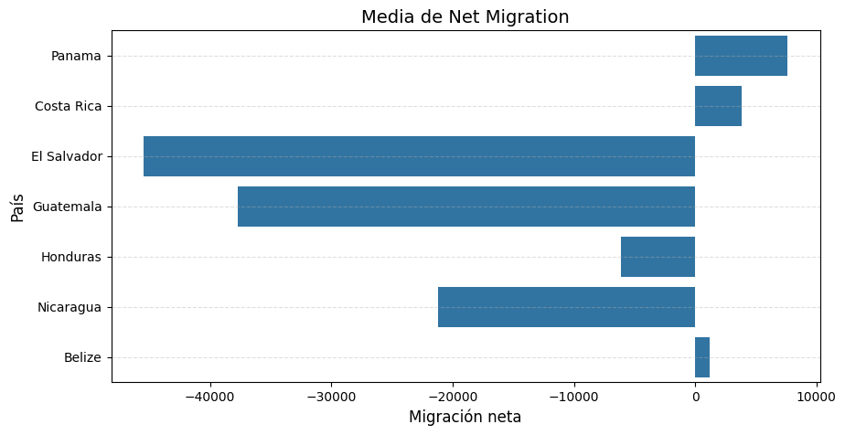

```python
import matplotlib.pyplot as plt
import seaborn as sns

dfNetMigration = dfNetMigration.T.mean() #cambiamos filas por columnas y calculamos la media de cada país

plt.figure(figsize=(10, 5))
sns.barplot(y=dfNetMigration.index, x=dfNetMigration)

plt.title('Media de Net Migration', fontsize=14)
plt.ylabel('País', fontsize=12)
plt.xlabel('Migración neta', fontsize=12)
plt.grid(axis='y', linestyle='--', alpha=0.4)
plt.show()
```

El gráfico anterior nos muestra la media de la migración neta de cada país centroamericano. Aquí podemos comprobar que en El Salvador, Guatmela, Honduras y Nicaragua, la migración neta es mayor, pero es negativa, lo que implica que la emigración es mucho más grande que la inmigración. Por otro lado, en Panamá, Costa Rica y Belice, la migración neta es positiva, lo que implica que la emigración es mucho más pequeña que la inmigración. Esto puede deberse a varias razones, como la presencia de ciudades y pueblos en cada país, la disponibilidad de recursos y la capacidad de los gobiernos para manejar la migración.

En general, la migración neta es una medida importante para evaluar la eficacia de la política de inmigración y emigración en un país. Sin embargo, es importante tener en cuenta que la migración neta no es la única medida de eficacia y que existen otras variables que deben ser consideradas, como la disponibilidad de recursos, la capacidad de los gobiernos para manejar la migración, la presencia de ciudades y pueblos, entre otros.

- **'People using at least basic sanitation services (% of population)':** Porcentaje de personas que utilizan al menos servicios básicos de saneamiento, es decir, instalaciones de saneamiento mejoradas que no se comparten con otros hogares. Este indicador abarca tanto a las personas que utilizan servicios básicos de saneamiento como a las que utilizan servicios de saneamiento gestionados de forma segura. Las instalaciones de saneamiento mejoradas incluyen el lavado y vertido de descarga a los sistemas de alcantarillado por tuberías, fosas sépticas o letrinas de pozo; Letrinas de pozo mejoradas ventiladas, inodoros de composición o letrinas de pozo con losas.

```python
# seleccionar las filas que contienen el indicador "People using at least basic sanitation services (% of population)"
dfBasicSanServices = df[df['Indicador'].str.contains('basic sanitation services')]
# Convertir columnas a numérico
dfBasicSanServices.iloc[:, 2:] = dfBasicSanServices.iloc[:, 2:].apply(pd.to_numeric, errors='coerce')
# eliminar la columna indicador
dfBasicSanServices = dfBasicSanServices.drop(columns=['Indicador'])
# elegimos la columna "País" como index y eliminamos la columna "País"
dfBasicSanServices.set_index('País', inplace=True)
# mostramos los datos
dfBasicSanServices
```

| País | 2010 | 2011 | 2012 | 2013 | 2014 | 2015 | 2016 | 2017 | 2018 | 2019 | 2020 | 2021 | 2022 |
| --- | --- | --- | --- | --- | --- | --- | --- | --- | --- | --- | --- | --- | --- |
| Panama | 72.964141 | 74.090213 | 75.224067 | 76.365718 | 77.515452 | 78.672737 | 79.837588 | 81.010299 | 82.190613 | 83.378552 | 84.573853 | 85.776812 | 85.879876 |
| Costa Rica | 95.922032 | 96.169038 | 96.406732 | 96.635596 | 96.856159 | 97.069017 | 97.274682 | 97.47361 | 97.666308 | 97.853222 | 98.034809 | 98.211466 | 98.383622 |
| El Salvador | 83.754774 | 84.128008 | 84.492976 | 84.849751 | 85.198961 | 85.540793 | 85.873731 | 86.197858 | 86.513661 | 86.821606 | 87.121986 | 87.391507 | 87.552784 |
| Guatemala | 65.369883 | 65.716311 | 66.053593 | 66.384806 | 66.709880 | 67.029272 | 67.342132 | 67.648933 | 67.949625 | 68.243669 | 68.531308 | 69.078034 | 69.621728 |
| Honduras | 74.039544 | 74.960123 | 75.870362 | 76.769845 | 77.659178 | 78.537895 | 79.406478 | 80.265022 | 81.113633 | 81.952553 | 82.782027 | 83.60218 | 84.396991 |
| Nicaragua | 66.942099 | 67.927325 | 68.911160 | 69.893603 | 70.874437 | 71.853883 | 72.831944 | 72.874822 | 72.920573 | 72.969399 | 73.021098 | NaN | NaN |
| Belize | 85.627708 | 85.942238 | 86.257854 | 86.574759 | 86.893045 | 87.212981 | 87.534777 | 87.858522 | 88.184416 | 88.198504 | 88.214277 | 88.231732 | 88.251078 |

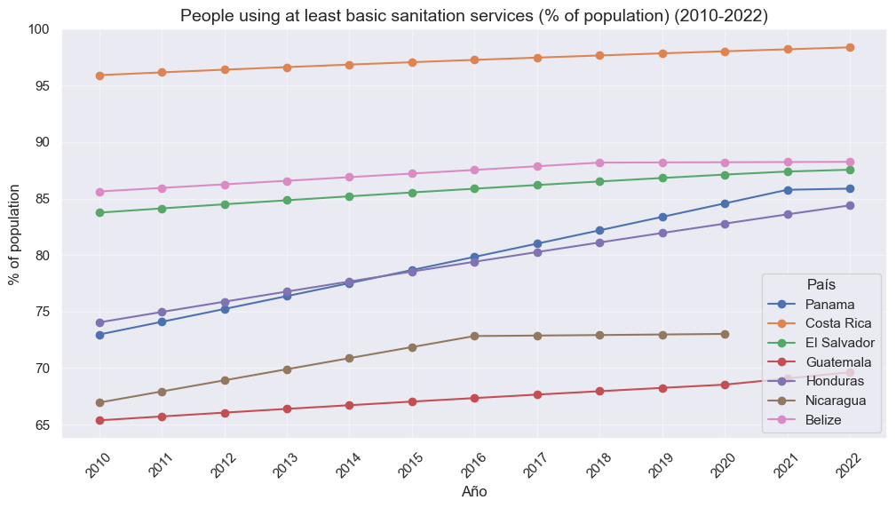

```python
import seaborn as sns
import matplotlib.pyplot as plt

plt.figure(figsize=(12, 6))

for pais in dfBasicSanServices.index:
    plt.plot(dfBasicSanServices.columns, dfBasicSanServices.loc[pais], marker='o', label=pais)

plt.title('People using at least basic sanitation services (% of population) (2010-2022)', fontsize=14)
plt.xlabel('Año', fontsize=12)
plt.ylabel('% of population', fontsize=12)
plt.xticks(rotation=45)
plt.legend(title='País')
plt.grid(alpha=0.4)
plt.show()
```

Podemos observar en el gráfico de arriba que el porcentaje de población que tiene acceso a servicios sanitarios básicos en Costa Rica es mayor por mucho en comparación con otros países de la región, se mantiene arriba del 95% a lo largo del tiempo. Mientras que en Guatemela, el porcentaje de población que tiene acceso a servicios sanitarios básicos es menor por mucho en comparación con otros países de la región, desde el 2010 hasta el año 2022 se mantiene por debajo del 70%. Esto sugiere que la situación de acceso a servicios sanitarios básicos en Costa Rica y Guatemala es muy diferente, y que esto puede tener implicaciones para la prevención y el control de la enfermedad en ambos países. Las razones de esto pueden variar, por ejemplo la disponibilidad de recursos humanos, la infraestructura existente, la legislación y la política de gobierno. En general, es importante tener en cuenta que los datos y análisis de los países pueden ser diferentes y que es necesario considerar estos factores cuando se compara la situación de acceso a servicios sanitarios básicos entre diferentes países.

```python
# Reemplazar los valores .. por 0 para que sea compatible con el cálculo de la media
dfBasicSanServices.replace('NaN', 0, inplace=True)
dfBasicSanServices
```

| País | 2010 | 2011 | 2012 | 2013 | 2014 | 2015 | 2016 | 2017 | 2018 | 2019 | 2020 | 2021 | 2022 |
| --- | --- | --- | --- | --- | --- | --- | --- | --- | --- | --- | --- | --- | --- |
| Panama | 72.964141 | 74.090213 | 75.224067 | 76.365718 | 77.515452 | 78.672737 | 79.837588 | 81.010299 | 82.190613 | 83.378552 | 84.573853 | 85.776812 | 85.879876 |
| Costa Rica | 95.922032 | 96.169038 | 96.406732 | 96.635596 | 96.856159 | 97.069017 | 97.274682 | 97.47361 | 97.666308 | 97.853222 | 98.034809 | 98.211466 | 98.383622 |
| El Salvador | 83.754774 | 84.128008 | 84.492976 | 84.849751 | 85.198961 | 85.540793 | 85.873731 | 86.197858 | 86.513661 | 86.821606 | 87.121986 | 87.391507 | 87.552784 |
| Guatemala | 65.369883 | 65.716311 | 66.053593 | 66.384806 | 66.709880 | 67.029272 | 67.342132 | 67.648933 | 67.949625 | 68.243669 | 68.531308 | 69.078034 | 69.621728 |
| Honduras | 74.039544 | 74.960123 | 75.870362 | 76.769845 | 77.659178 | 78.537895 | 79.406478 | 80.265022 | 81.113633 | 81.952553 | 82.782027 | 83.60218 | 84.396991 |
| Nicaragua | 66.942099 | 67.927325 | 68.911160 | 69.893603 | 70.874437 | 71.853883 | 72.831944 | 72.874822 | 72.920573 | 72.969399 | 73.021098 | NaN | NaN |
| Belize | 85.627708 | 85.942238 | 86.257854 | 86.574759 | 86.893045 | 87.212981 | 87.534777 | 87.858522 | 88.184416 | 88.198504 | 88.214277 | 88.231732 | 88.251078 |

```python
#convertir todos los datos tipo float
dfBasicSanServices = dfBasicSanServices.astype(float)
#reemplazar los valores nulos en la fila 'Nicaragua' por el promedio de los datos de esta
dfBasicSanServices.replace(0, dfBasicSanServices.iloc[5].mean(), inplace=True)
dfBasicSanServices
```

| País | 2010 | 2011 | 2012 | 2013 | 2014 | 2015 | 2016 | 2017 | 2018 | 2019 | 2020 | 2021 | 2022 |
| --- | --- | --- | --- | --- | --- | --- | --- | --- | --- | --- | --- | --- | --- |
| Panama | 72.964141 | 74.090213 | 75.224067 | 76.365718 | 77.515452 | 78.672737 | 79.837588 | 81.010299 | 82.190613 | 83.378552 | 84.573853 | 85.776812 | 85.879876 |
| Costa Rica | 95.922032 | 96.169038 | 96.406732 | 96.635596 | 96.856159 | 97.069017 | 97.274682 | 97.473610 | 97.666308 | 97.853222 | 98.034809 | 98.211466 | 98.383622 |
| El Salvador | 83.754774 | 84.128008 | 84.492976 | 84.849751 | 85.198961 | 85.540793 | 85.873731 | 86.197858 | 86.513661 | 86.821606 | 87.121986 | 87.391507 | 87.552784 |
| Guatemala | 65.369883 | 65.716311 | 66.053593 | 66.384806 | 66.709880 | 67.029272 | 67.342132 | 67.648933 | 67.949625 | 68.243669 | 68.531308 | 69.078034 | 69.621728 |
| Honduras | 74.039544 | 74.960123 | 75.870362 | 76.769845 | 77.659178 | 78.537895 | 79.406478 | 80.265022 | 81.113633 | 81.952553 | 82.782027 | 83.602180 | 84.396991 |
| Nicaragua | 66.942099 | 67.927325 | 68.911160 | 69.893603 | 70.874437 | 71.853883 | 72.831944 | 72.874822 | 72.920573 | 72.969399 | 73.021098 | NaN | NaN |
| Belize | 85.627708 | 85.942238 | 86.257854 | 86.574759 | 86.893045 | 87.212981 | 87.534777 | 87.858522 | 88.184416 | 88.198504 | 88.214277 | 88.231732 | 88.251078 |

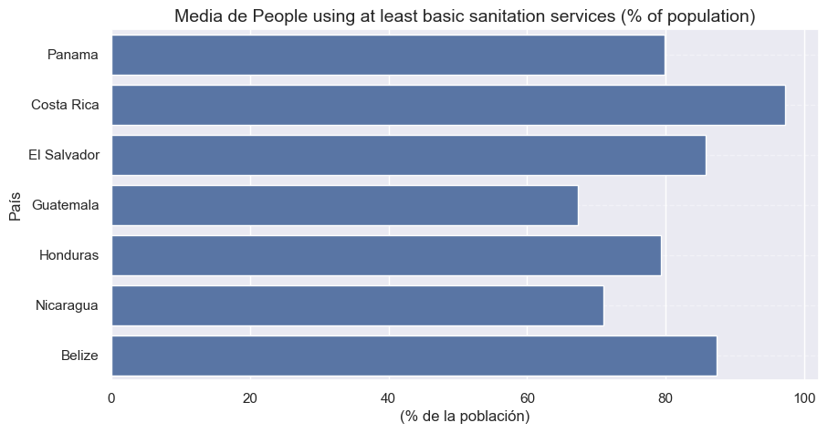

```python
import matplotlib.pyplot as plt
import seaborn as sns

dfBasicSanServices = dfBasicSanServices.T.mean() #cambiamos filas por columnas y calculamos la media de cada país

plt.figure(figsize=(10, 5))
sns.barplot(y=dfBasicSanServices.index, x=dfBasicSanServices)

plt.title('Media de People using at least basic sanitation services (% of population)', fontsize=14)
plt.ylabel('País', fontsize=12)
plt.xlabel('(% de la población)', fontsize=12)
plt.grid(axis='y', linestyle='--', alpha=0.4)
plt.show()
```

En este gráfico podemos comparar los promedios de porcentaje de población que tiene acceso a servicios sanitarios básicos en cada país, comprobamos que Costa Rica tiene el mayor porcentaje de población con acceso a servicios sanitarios básicos, y que por tanto tiene la mayor cantidad de población con acceso a servicios sanitarios básicos en la región centroamericana. Mientras que en países como Nicaragua, Guatemala y Honduras, aún les falta cubrir un buen porcentaje de la población con acceso a servicios sanitarios básicos.

- **'Population density (people per sq. km of land area)':** La densidad de población se calcula dividiendo la población a mitad de año por la superficie terrestre en kilómetros cuadrados

```python
# seleccionar las filas que contienen el indicador "Population density (people per sq. km of land area)"
dfPopulationDensity = df[df['Indicador'].str.contains('Population density')]
# Convertir columnas a numérico
dfPopulationDensity.iloc[:, 2:] = dfPopulationDensity.iloc[:, 2:].apply(pd.to_numeric, errors='coerce')
# eliminar la columna indicador y la columna "2022" porque no tiene ningún dato
dfPopulationDensity = dfPopulationDensity.drop(columns=['Indicador', '2022'])
# elegimos la columna "País" como index y eliminamos la columna "País"
dfPopulationDensity.set_index('País', inplace=True)
# mostramos los datos
dfPopulationDensity
```

| País | 2010 | 2011 | 2012 | 2013 | 2014 | 2015 | 2016 | 2017 | 2018 | 2019 | 2020 | 2021 |
| --- | --- | --- | --- | --- | --- | --- | --- | --- | --- | --- | --- | --- |
| Panama | 48.743839 | 49.618967 | 50.509309 | 51.406457 | 52.466176 | 53.387736 | 54.321856 | 55.262588 | 56.150647 | 57.05759 | 57.891561 | 58.658223 |
| Costa Rica | 90.525891 | 91.655425 | 92.765237 | 93.841265 | 94.874422 | 95.872346 | 96.850862 | 97.803408 | 98.721778 | 99.579553 | 100.334998 | 100.939228 |
| El Salvador | 295.078861 | 296.204102 | 297.359508 | 298.534846 | 299.687548 | 300.727124 | 301.665541 | 302.444691 | 302.912259 | 303.099276 | 303.703234 | 304.73779 |
| Guatemala | 133.069121 | 135.512458 | 137.942721 | 140.388027 | 142.836096 | 145.272667 | 147.701474 | 150.125215 | 152.547126 | 154.946118 | 157.31927 | 159.665416 |
| Honduras | 75.528939 | 77.062329 | 78.580454 | 80.084521 | 81.578747 | 83.068237 | 84.554455 | 86.038448 | 87.52212 | 89.005532 | 90.46173 | 91.861158 |
| Nicaragua | 48.659914 | 49.381361 | 50.113071 | 50.850748 | 51.592787 | 52.34002 | 53.093194 | 53.851853 | 54.613869 | 55.375802 | 56.140061 | 56.926541 |
| Belize | 14.121263 | 14.447085 | 14.776808 | 15.111267 | 15.446515 | 15.776896 | 16.103157 | 16.426699 | 16.749934 | 17.058089 | 17.313503 | 17.537527 |

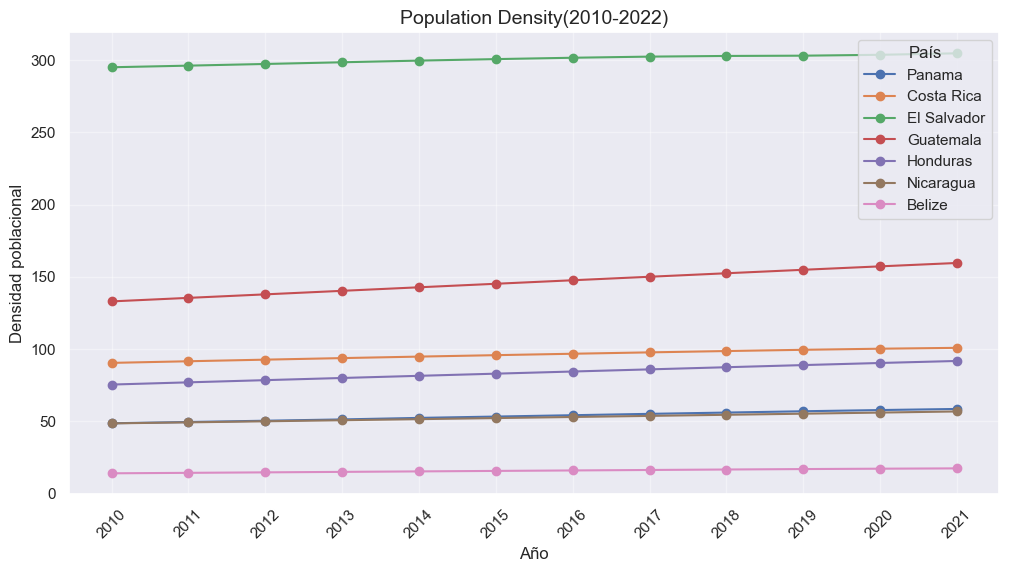

```python
import seaborn as sns
import matplotlib.pyplot as plt

plt.figure(figsize=(12, 6))

for pais in dfPopulationDensity.index:
    plt.plot(dfPopulationDensity.columns, dfPopulationDensity.loc[pais], marker='o', label=pais)

plt.title('Population Density(2010-2022)', fontsize=14)
plt.xlabel('Año', fontsize=12)
plt.ylabel('Densidad poblacional', fontsize=12)
plt.xticks(rotation=45)
plt.legend(title='País')
plt.grid(alpha=0.4)
plt.show()
```

El gráfico nos muestra la evolución de la densidad poblacional en cada país a través de los años. Podemos notar que el país con mayor densidad poblacional es, por mucho, El Salvador, teniendo que entre los años 2010 a 2022 viven aproximadamente 295 a 304 personas por cada km². Esto puede indicar que hay o puede haber una sobrepoblación en este país, ya que el área territorial de El Salvador es de 21,041 km² y su densidad poblacional es alta en comparación con la densidad de población del resto de países de la región centroamericana, quienes tienen más área territorial. Mientras que en otros países, como Belice, Nicaragua y Panamá, la densidad poblacional es mucho menor, lo que sugiere que hay una baja población en estos países. En general, es importante tener en cuenta la densidad poblacional para entender la evolución de la población en un país determinado.

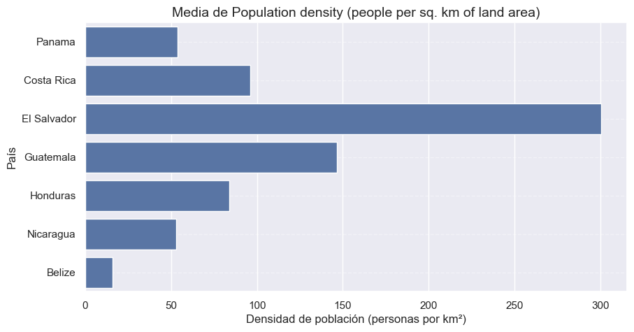

```python
import matplotlib.pyplot as plt
import seaborn as sns

dfPopulationDensity = dfPopulationDensity.T.mean() #cambiamos filas por columnas y calculamos la media de cada país

plt.figure(figsize=(10, 5))
sns.barplot(y=dfPopulationDensity.index, x=dfPopulationDensity)

plt.title('Media de Population density (people per sq. km of land area)', fontsize=14)
plt.ylabel('País', fontsize=12)
plt.xlabel('Densidad de población (personas por km²)', fontsize=12)
plt.grid(axis='y', linestyle='--', alpha=0.4)
plt.show()
```

En este gráfico de barras se muestra el promedio de densidad poblacional de cada país, podemos comprobar que el país con mayor densidad poblacional es El Salvador, con una densidad poblacional promedio de 300 personas por km², aproximadamente. En el resto de países se observan distribuciones con densidades poblacionales menores, por ejemplo, en Guatemala con una densidad poblacional de 146 personas por km², y en Honduras con una densidad poblacional de 83 personas por km². Estas diferencias en la distribución poblacional pueden tener un impacto significativo en la forma en que se comportan las personas en el país, ya que las personas con menor densidad poblacional tienden a vivir en zonas más pobres y menos accesibles, mientras que las personas con mayor densidad poblacional tienden a vivir en zonas más ricas y accesibles. Aunque en ocasiones, esto no necesariamente significa que las personas con mayor densidad poblacional son más vulnerables a la pobreza, pues la pobreza puede afectar a la distribución poblacional en diferentes maneras, como la falta de acceso a servicios básicos como agua potable y educación. En general, es importante considerar la distribución poblacional cuando se está analizando la pobreza y la vulnerabilidad de las personas en un país.